# **Chapter 4: Introduction to Threads and Concurrency**

#### **1. The Shift from Single-Threaded to Multi-Threaded Processes**

In the previous chapter (Chapter 3), a **process** was defined as a program in execution. A key part of that definition was that it had a **single thread of control**. Think of this as a single pointer (like the Program Counter in your computer architecture knowledge) moving sequentially through the instructions of the program. Even if the program was doing multiple things, it was doing them one after another.

However, this model is limited. Modern operating systems allow a **single process to contain multiple threads of control**. Each thread is like a separate, lightweight agent within the process that can execute code independently.

#### **2. Why Threads? The Drive for Parallelism**

The primary motivation for using threads is to exploit **parallelism**. This has become critically important with the advent of **multicore systems** (CPUs with multiple processing cores).

- **Analogy:** Imagine a kitchen with one chef (a single-threaded process). The chef must chop vegetables, boil water, and season the meat one task at a. Now, imagine a kitchen with multiple chefs (multiple threads within one process). They can work on different tasks *simultaneously*, dramatically speeding up the overall cooking process.
- **Technical Connection:** Your computer architecture course taught you about multicore processors. Threads are the software mechanism that allows you to actually *use* those multiple cores effectively within a single application. Without threads, a process could only ever run on one CPU core at a time, wasting the potential of the others.

#### **3. What This Chapter Will Cover**

This chapter serves as a roadmap. It will introduce you to:

- **The Concepts and Challenges:** Using multiple threads isn't simple. We will discuss the new problems that arise, such as coordination and data sharing between threads.
- **Threading APIs:** We will look at the specific programming interfaces used to create and manage threads, focusing on three major libraries:
  - **Pthreads:** The standard threading API for UNIX/Linux-like systems.
  - **Windows Threads:** The threading API for the Windows operating system.
  - **Java Threads:** How threading is implemented in the Java programming language, which manages threads through its Virtual Machine.
- **Higher-Level Abstractions:** We will explore modern features that hide the complex details of thread management from the programmer. The goal here is to let developers focus on *identifying what can be done in parallel*, while the system's frameworks handle the "how" of creating and managing the threads.
- **Operating System Design Impact:** We will examine how the existence of threads influences the design of the operating system kernel itself.
- **Kernel-Level Thread Support:** Finally, we will take a close look at how two real-world operating systems, **Windows** and **Linux**, implement and support threads within their kernels.

This chapter lays the foundation for understanding how modern software can efficiently utilize modern hardware.

## **4.1 Overview: What is a Thread?**

Think of a thread as a lightweight, streamlined version of a process. You already know from computer architecture that a process requires a lot of overhead: it has its own dedicated memory space (code, data, heap, stack), file descriptors, and more. A thread is a way to break a process down into smaller, executable units.

**The Technical Definition:** A **thread** is a basic unit of CPU utilization. Its core components, which you are familiar with from the CPU's perspective, are:

- **Thread ID:** A unique identifier.
- **Program Counter (PC):** Tracks which instruction to execute next.
- **Register Set:** Holds the current working variables of the thread.
- **Stack:** Contains the thread's execution history (function calls, local variables).

**The Key Difference from a Process:** While a thread has these independent components, it **shares** everything else with other threads belonging to the same process. This includes:

- The **code section** (the program instructions).
- The **data section** (global variables).
- Other OS resources like **open files** and signals.

This makes threads "lightweight" because creating a new thread doesn't require duplicating all of this shared context, unlike creating a new process.

**Single-threaded vs. Multithreaded Processes:**

- A **traditional, single-threaded process** has just one "thread of control." One program counter, one sequence of instructions.
- A **multithreaded process** has multiple threads, meaning it can have multiple program counters and multiple sequences of instructions executing at the same time (or seemingly at the same time on a single core).

**Refer to Figure 4.1:** This figure perfectly illustrates the difference. The single-threaded process has one set of registers, one stack, and one PC. The multithreaded process has multiple sets of registers, multiple stacks, and multiple PCs, all operating within a single shared code and data space.

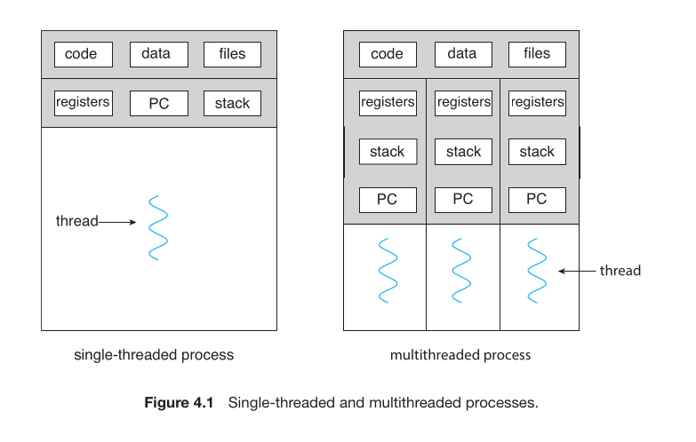

### **4.1.1 Motivation: Why Do We Need Threads?**

Virtually all modern applications use threads. The motivation comes from two main areas: improving application responsiveness and efficiently using modern hardware.

**1. Improved Application Structure and Responsiveness:** Even on a single-core CPU, threads can make an application feel more responsive by allowing it to perform multiple tasks *concurrently*. The OS rapidly switches between threads, giving the user the illusion that many things are happening at once.

**Real-world examples from your text:**

- **Photo Thumbnail Generator:** A separate thread can be spawned to process each image. This is more efficient than processing one image completely before starting the next.
- **Web Browser:** One thread can handle the UI (displaying content) while another thread performs network communication (downloading data). This prevents the entire browser from freezing while waiting for a slow network.
- **Word Processor:** One thread for user input, another for display, and a third for background spell-checking. This allows you to keep typing while the program checks your spelling.

**2. Leveraging Multicore Architectures:** You learned in computer architecture that modern CPUs have multiple cores. A single-threaded process can only run on one core at a time, leaving the others idle. A **multithreaded application can be designed to run its threads on multiple cores simultaneously**, leading to a true performance increase for CPU-intensive tasks like data mining, scientific computing, and graphics rendering.

**3. The Server Example: Economic Resource Usage** This is a critical concept. Let's analyze the web server example in detail.

- **The Problem:** A busy web server gets thousands of requests. A single-threaded server can only handle one request at a time. Everyone else waits.
- **The Old Solution: Process-per-request.** The server would create a brand new *process* for each incoming request. As you know, process creation is **heavyweight**—it involves duplicating the entire parent's memory space, which is slow and consumes a lot of RAM.
- **The Modern Solution: Thread-per-request.** The server runs as a single, multithreaded process. One main thread listens for connections. When a request comes in, the server creates a new *thread* to handle it. Thread creation is **lightweight** because the new thread shares the existing process's code, data, and files. It only needs its own stack and registers. This is vastly more efficient and scalable.

**Refer to Figure 4.2:** This diagram shows the server architecture. Step 1: A request comes in. Step 2: The server creates a new thread *inside its own process* to service that request. Step 3: The main thread immediately goes back to listening for more requests.

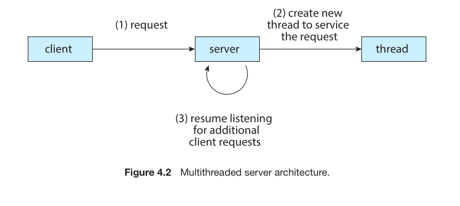

**4. Operating System Kernels:** Even the OS itself uses threads. The Linux kernel, for example, starts threads like `kthreadd` (you can see it using `ps -ef`) to manage specific tasks like handling devices or memory. This makes the kernel more modular and responsive.

**In Summary:** Threads provide a powerful tool for programmers to design applications that are more responsive, resource-efficient, and capable of exploiting the parallel processing power of multicore systems.

### **4.1.2 Benefits of Multithreaded Programming**

Using multiple threads within a single program provides several major advantages. These benefits are often categorized into four key areas, which build directly on the concepts you learned in computer architecture about processes and context switching.

#### **1. Responsiveness**

**What it means:** Multithreading can keep an application responsive and interactive even when parts of it are busy with long-running tasks.

**Detailed Explanation:** In a single-threaded application, the entire program has only one thread of control. If that one thread becomes busy (e.g., performing a complex calculation, reading a large file from a slow disk, or waiting for a network response), the entire program freezes. The user interface (UI) will not update and will not respond to any user input.

In a multithreaded design, the time-consuming task is assigned to a **background thread** (also called a worker thread). The main thread, which is responsible for the UI, remains free to continuously listen for and react to user actions like clicks and keystrokes. This gives the user immediate feedback, such as showing a progress bar or allowing them to cancel the operation, making the application feel much smoother and more responsive.

- **Example from text:** When a user clicks a button that triggers a long operation, a separate thread handles the operation, so the UI doesn't lock up.

#### **2. Resource Sharing**

**What it means:** Threads within the same process can easily and automatically share data and resources with each other.

**Detailed Explanation:** By default, threads share the entire address space of their parent process—this includes the code, global variables, and heap memory. This is a built-in feature of the threading model.

In contrast, processes are isolated from each other by the operating system. For processes to share data, the programmer must use more complex and slower **Inter-Process Communication (IPC)** techniques, such as:

- **Shared Memory:** A region of memory is explicitly set up to be accessible by multiple processes.
- **Message Passing:** Data is explicitly copied from one process's address space to another's using mechanisms like pipes or message queues.

Threads avoid this overhead. This inherent sharing allows for efficient collaboration, such as multiple threads working on different parts of the same large data structure.

#### **3. Economy**

**What it means:** Threads are significantly cheaper to create and manage than processes.

**Detailed Explanation:** This point relates directly to performance and resource usage. Creating a process is a heavy-weight operation because the operating system must:

- Allocate a new and separate memory space for code, data, heap, and stack.
- Set up numerous kernel data structures to manage the process (e.g., Process Control Block, file descriptor table).

Creating a thread is a light-weight operation because the new thread:

- Shares the existing process's code, data, and files.
- Only requires the OS to allocate a small, new stack and a Thread Control Block (TCB) to manage its register set, PC, and state.

Furthermore, **context switching between threads is faster** than between processes. A thread context switch within the same process does not require invalidating the Translation Lookaside Buffer (TLB) because the memory address space does not change. A process context switch requires switching the memory address space, which often leads to a TLB flush, causing more cache misses and a higher performance penalty.

#### **4. Scalability**

**What it means:** Multithreaded applications can directly exploit the power of systems with multiple CPUs or multiple processor cores.

**Detailed Explanation:** This is a critical benefit for modern multicore systems, which you studied in computer architecture. A single-threaded process is inherently limited to running on a single processor core at any given moment, no matter how many idle cores are available.

A multithreaded application, however, can be designed so that its workload is divided among several threads. The operating system can then schedule these threads to run **simultaneously on different cores**. This allows for true parallel execution, dramatically reducing the total time required for CPU-intensive tasks like rendering a video, simulating a physical system, or querying a large database. The more cores available, the more a well-designed multithreaded application can scale its performance.

## **4.2 Multicore Programming**

This section discusses the fundamental shift in computing from single-core to multi-core processors and how this changes the way we think about threads.

#### **The Shift to Multicore Systems**

**Historical Context:** The demand for more computing power first led to systems with multiple, separate CPU chips on a single motherboard. A more recent and prevalent trend is to place multiple independent processing units, called **cores**, onto a single chip. Each core is capable of executing its own stream of instructions. From the operating system's perspective, each core appears as a separate CPU.

**The Role of Multithreading:** Multithreaded programming is the primary mechanism for an application to take full advantage of these multiple cores, leading to more efficient resource use and true parallel execution.

#### **Concurrency vs. Parallelism**

This is a critical distinction that builds directly on your knowledge of CPU scheduling.

**Concurrency:**

- A system is **concurrent** if it supports more than one task making progress.
- It does *not* require multiple cores. On a single-core system, concurrency is achieved by the operating system's scheduler rapidly switching the single CPU between multiple threads (a context switch you're familiar with). Each thread gets a small time slice to run, creating the *illusion* of simultaneous execution.
- **Refer to Figure 4.3:** This diagram shows concurrent execution on a single-core system. Threads T1, T2, T3, and T4 are all making progress over time, but only one is actually executing on the CPU at any given instant. Their execution is **interleaved**.

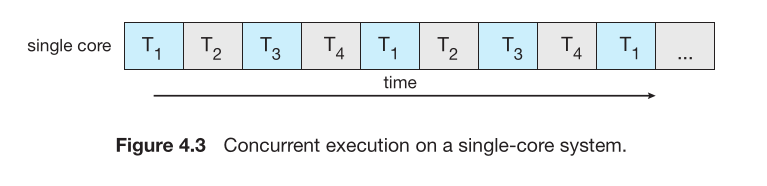

**Parallelism:**

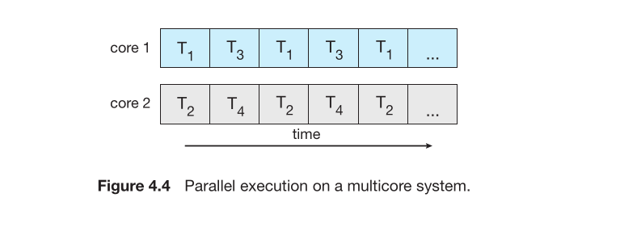

**The Key Takeaway:** **You can have concurrency without parallelism, but you cannot have parallelism without a system that supports concurrent execution (like a multicore CPU).**

Before multicore systems were common, single-CPU computers used concurrency (via time-sharing) to allow multiple applications to run "at the same time," even though they were never actually executing instructions in parallel. Multicore systems allow us to move from this interleaved concurrency to true parallelism.

### **4.2.1 Programming Challenges**

While multicore systems offer the potential for massive performance gains, this potential comes with significant new challenges for programmers. Simply having multiple cores does not make an application faster; the application must be explicitly designed to leverage them. This shift is so fundamental that it is changing how software is designed and how computer science is taught.

Here are the five key challenges in programming for multicore systems:

#### **1. Identifying Tasks**

**The Challenge:** The programmer must analyze an application and decompose its workload into discrete units of work, or **tasks**, that can be executed concurrently.

**Detailed Explanation:** This is the first and most crucial step. You need to find parts of the program that can run at the same time. The ideal scenario is to identify tasks that are **independent**—meaning they do not need to communicate with or wait for each other. This allows them to run in parallel on different cores with minimal coordination overhead.

- **Example:** In a photo thumbnail application, creating a thumbnail for each image is a perfectly independent task. These tasks are easy to run in parallel.

#### **2. Balance**

**The Challenge:** After identifying tasks, the programmer must ensure that the work is distributed evenly across the tasks. This is also known as **load balancing**.

**Detailed Explanation:** If you spawn eight threads but one thread does 90% of the work while the other seven finish quickly and sit idle, you have gained very little from having eight cores. The goal is to divide the work so that all cores are kept busy for roughly the same amount of time. Furthermore, all tasks should be of roughly "equal value"; it's not efficient to dedicate a core to a trivial task whose setup and management costs more than just executing it on a single core.

#### **3. Data Splitting**

**The Challenge:** The data that the application operates on must be divided up to match the division of tasks.

**Detailed Explanation:** You can't just split the code; you must also split the data it processes. If multiple threads need to work on a large array, for example, you should split the array into chunks so that each thread can work on its own separate portion of the data. This minimizes conflicts and is the foundation for **data parallelism**.

**Refer to Figure 4.5:** This figure illustrates the two fundamental parallel programming models. In **Data Parallelism**, the same task (operation) is performed in parallel on different subsets of the same data. In **Task Parallelism**, different threads execute different tasks (functions) on potentially the same or different data.

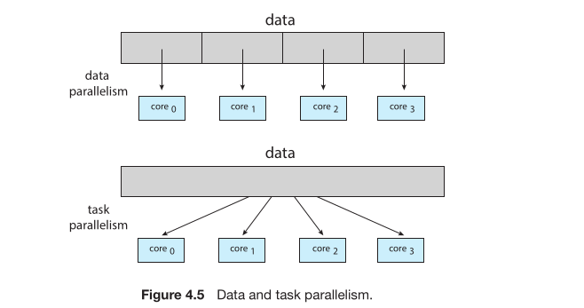

#### **4. Data Dependency**

**The Challenge:** Tasks often are not independent and must share data or communicate results. This creates dependencies where one task cannot proceed until another has finished a certain part of its work.

**Detailed Explanation:** This is one of the hardest parts of concurrent programming. If Task B requires a result computed by Task A, the program must be **synchronized** to ensure Task B does not read the data before Task A has finished writing it. Incorrect handling of data dependencies leads to severe bugs like **race conditions**, where the program's outcome depends on the unpredictable timing of the threads. Strategies to handle this (e.g., mutex locks, semaphores) are complex and will be covered in detail in Chapter 6.

#### **5. Testing and Debugging**

**The Challenge:** Testing and debugging multithreaded programs is inherently more difficult than for single-threaded programs.

**Detailed Explanation:** A single-threaded program has one, predictable path of execution. A multithreaded program has a vast number of possible execution paths because the operating system scheduler can interleave the threads in many different orders across the cores. A bug that only occurs under a very specific and rare timing of events may be nearly impossible to reproduce and find. Traditional debugging techniques are often inadequate for these types of concurrency bugs.

#### **Amdahl's Law**

Amdahl's Law is a fundamental principle in computer architecture and parallel computing that provides a realistic prediction of the maximum potential speedup a program can achieve when additional computing cores are added. It highlights a critical limitation: the **serial (non-parallel) portion** of a program ultimately limits its scalability.

##### **The Formula and Its Components**

The formula for Amdahl's Law is:

**speedup ≤ 1 / (S + (1 - S)/N)**

Where:

- **speedup:** The theoretical maximum speedup of the entire task.
- **S:** The **serial fraction** of the program. This is the portion that *cannot* be parallelized and must run on a single core.
- **N:** The number of **processing cores**.
- **(1 - S):** The **parallel fraction** of the program. This is the portion that can be divided and executed across multiple cores.

##### **Detailed Explanation and Example**

The formula calculates the total time the program would take on a multi-core system and compares it to the time on a single-core system. The new execution time is the sum of the serial part and the parallel part divided by N.

Let's use the example from your text:

- The application is **75% parallel**, meaning the parallel fraction `(1 - S) = 0.75`.
- Therefore, the serial fraction `S = 0.25` (or 25%).

**With 2 processing cores (N=2):** speedup ≤ 1 / (0.25 + (0.75)/2) = 1 / (0.25 + 0.375) = 1 / 0.625 = **1.6**

This means the best speedup we can expect on two cores is 1.6 times faster than on a single core.

**With 4 processing cores (N=4):** speedup ≤ 1 / (0.25 + (0.75)/4) = 1 / (0.25 + 0.1875) = 1 / 0.4375 ≈ **2.28**

Adding two more cores provides a performance increase, but it is not a linear scaling (we didn't get 3.2x speedup).

##### **The Critical Implication: The Law of Diminishing Returns**

The most important insight from Amdahl's Law is that **as the number of cores (N) approaches infinity, the maximum possible speedup converges to 1/S.**

**From the example:** If `S = 0.5` (50% of the program is serial), the maximum speedup is: speedup ≤ 1 / 0.5 = **2**

This means that no matter how many thousands of cores you add—if half of your program is inherently sequential—the absolute maximum you can make it run is two times faster. This is why the serial portion has a "disproportionate effect." A small serial component creates a hard ceiling on performance.

**In summary:** Amdahl's Law teaches programmers that to achieve significant speedups on multicore systems, the primary goal must be to **minimize the serial portion (S)** of their code. Designing algorithms that are as parallel as possible is essential.

### **4.2.2 Types of Parallelism**

To effectively design programs for multicore systems, we categorize parallel execution into two main strategies. These strategies determine how work is divided among threads and cores.

#### **1. Data Parallelism**

**Definition:** **Data parallelism** focuses on distributing subsets of the *same data* across multiple computing cores and having each core perform the *same operation* on its subset.

**Detailed Explanation:** In this model, the operation (the task) is fixed and singular. The key is to split the data into chunks that can be processed independently and simultaneously. This is often easier to implement when the operation on one piece of data does not depend on the result from another.

**Example from the text:** Summing the contents of a large array.

- On a **single-core system**, one thread iterates through all N elements.
- On a **dual-core system**:
  - **Thread A** (on Core 0) sums the first half of the array: elements `[0] ... [N/2 - 1]`.
  - **Thread B** (on Core 1) sums the second half of the array: elements `[N/2] ... [N - 1]`.
- After both threads finish, their partial sums are combined to get the final total.

The core operation (summation) is identical for both threads; only the data they work on is different.

#### **2. Task Parallelism**

**Definition:** **Task parallelism** involves distributing distinct *tasks* (threads) across multiple computing cores. Each thread can perform a unique operation, and they may operate on the same data, different data, or a combination.

**Detailed Explanation:** This model emphasizes the diversity of the work being done. Instead of repeating the same operation on different data, different cores are executing entirely different functions or parts of the program's logic concurrently.

**Example from the text:** Performing statistical operations on an array.

- **Thread A** (on Core 0) could be calculating the average of the array.
- **Thread B** (on Core 1) could simultaneously be finding the maximum and minimum values in the same array.

Here, the threads are performing different tasks (`calculate average` vs. `find min/max`). They might both be reading from the same array, but they are executing different code.

**Refer to Figure 4.5:** This figure provides a clear visual distinction.

#### **Hybrid Approach**

The text makes a crucial point: **data and task parallelism are not mutually exclusive.** A complex application will often use a hybrid strategy.

**Example:** A video processing application might use:

- **Task Parallelism:** One set of threads handles decoding the video, another set handles processing the audio, and a third handles applying visual effects.
- **Data Parallelism *within* a Task:** The "visual effects" task could itself use data parallelism, where multiple threads work on different portions of the same video frame to apply a filter more quickly.

Understanding these two types allows a programmer to choose the right strategy—or combination of strategies—to most effectively decompose a problem for parallel execution.

## **4.3 Multithreading Models**

This section explains the crucial relationship between the threads an application uses and how the operating system sees them. This relationship is fundamental to how your multithreaded program actually runs on the hardware.

#### **User Threads vs. Kernel Threads**

First, we must define two key concepts:

- **User Threads:** These are threads that are managed entirely by a **user-level thread library** (like Java's threads or POSIX Pthreads) without direct support from the operating system kernel. The OS is completely unaware of these threads; it only sees the process as a single unit.
- **Kernel Threads:** These are threads that are supported and managed directly by the **operating system kernel**. The kernel schedules kernel threads, not processes.

**Refer to Figure 4.6:** This figure illustrates the fundamental relationship. The user threads exist in the application's user space, while the kernel threads are managed within the OS kernel space. The "Multithreading Model" is the mapping that connects these two layers.

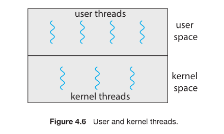

### **4.3.1 Many-to-One Model**

**Definition:** The **Many-to-One model** maps many user-level threads to a single kernel thread.

**Detailed Explanation:** In this model, thread creation, scheduling, and management (all the work of context switching between threads) are done by a thread library in the user space. This is very efficient because it doesn't require making a system call (a request to the kernel) for every thread operation like a context switch.

However, this model has two major, critical disadvantages:

1. **Blocking System Calls:** Since the OS kernel only sees one kernel thread (the entire process), if one user thread makes a **blocking system call** (like reading from a slow disk or network), the single kernel thread blocks. This causes the **entire process** to block, freezing all other user threads inside that process, even if they have work they could be doing.
2. **No True Parallelism:** Because there is only one kernel thread associated with the process, the OS can only schedule that one thread on one CPU core. Even on a multicore system, the multiple user threads within the process cannot run **in parallel** on different cores; they can only run concurrently through interleaving on a single core.

**Refer to Figure 4.7:** This diagram shows the many-to-one model. Notice how multiple user threads in the user space all funnel down through a single, central connection to one kernel thread in the kernel space.

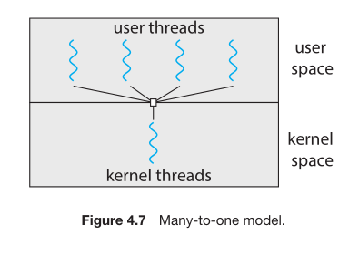

**Historical Context and Modern Relevance:** The text mentions **Green threads**, which used this model and were part of early Java versions. Because of the severe limitations listed above, the many-to-one model has been largely abandoned in modern operating systems and programming languages. Its inability to leverage multiple cores makes it unsuitable for contemporary hardware.

### **4.3.2 One-to-One Model**

**Definition:** The **One-to-One model** maps each user-level thread to its own dedicated kernel thread.

#### **Detailed Explanation**

This model creates a direct, one-to-one correspondence between the threads your application uses (user threads) and the entities the operating system scheduler manages (kernel threads).

**Advantages:**

1. **True Parallelism and Concurrency:** This is the primary advantage. Because each user thread is backed by its own kernel thread, the operating system scheduler can assign different threads to different CPU cores. This allows a multithreaded process to achieve **true parallel execution** on a multicore system.
2. **No Blocking on System Calls:** If one user thread makes a blocking system call (e.g., waiting for I/O), only that one kernel thread blocks. The OS scheduler can immediately switch to another, ready-to-run kernel thread within the same process (or a different process). This keeps the CPU busy and allows other threads in the application to continue making progress.

**Disadvantage:**

- **Overhead and Scalability Limitation:** The major drawback is overhead. Creating a user thread necessitates creating a corresponding kernel thread. Kernel thread creation is a heavyweight operation that consumes significant kernel resources and time. Furthermore, each kernel thread requires memory for its kernel-level data structures (like a Thread Control Block). As a result, there is often a hard limit on the total number of threads a system can support, and creating a very large number of threads (thousands) can severely burden the system and degrade overall performance.

**Refer to Figure 4.8:** This diagram illustrates the one-to-one model. You can see a direct, one-to-one mapping between each user thread in user space and each kernel thread in kernel space.

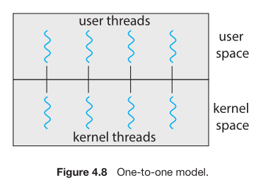

**Modern Usage:** This is the dominant model used in modern major operating systems. **Linux, Windows, and macOS** all implement the one-to-one model. This is why these systems can effectively leverage multicore processors for multithreaded applications, despite the higher per-thread cost.

### **4.3.3 Many-to-Many Model**

**Definition:** The **Many-to-Many model** multiplexes (or maps) many user-level threads to a smaller or equal number of kernel threads.

#### **Detailed Explanation**

This model attempts to combine the best features of the previous two models while eliminating their main drawbacks.

**How it Works:** A thread library in user space manages a pool of user threads. The application can create a very large number of these user threads. This pool is then executed by a smaller set of kernel threads, the number of which is controlled by the OS or the thread library, often based on the number of available CPU cores.

**Advantages:**

1. **Concurrency and Parallelism:** Unlike the many-to-one model, the presence of multiple kernel threads allows the OS to schedule them on multiple cores, enabling **true parallelism**. If one kernel thread blocks on a system call, the OS can immediately schedule another kernel thread from the same process.
2. **Efficiency and Scalability:** Unlike the one-to-one model, the application is not limited by the high cost of kernel threads. A programmer can create thousands of user threads without overburdening the OS, as only a manageable number of kernel threads are ever in existence. This provides great flexibility.

**Refer to Figure 4.9:** This diagram shows the many-to-many model. Notice how a large number of user threads are mapped to a smaller pool of kernel threads.

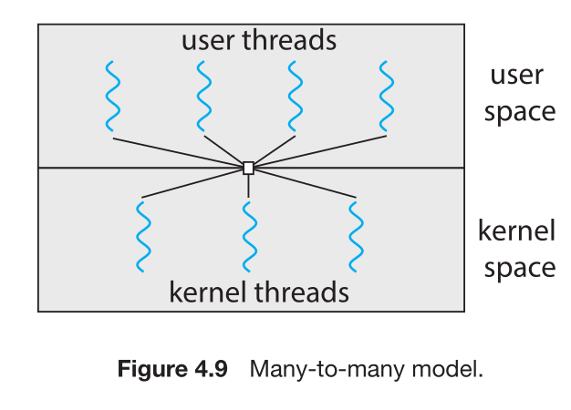

### **The Two-Level Model**

**Definition:** The **Two-Level model** is a variation of the many-to-many model. It multiplexes many user threads to a pool of kernel threads, but it also allows a certain number of user threads to be permanently **bound** to a dedicated kernel thread.

**Detailed Explanation:** This model adds an extra layer of flexibility. It allows the thread library to treat some user threads as "special" by giving them a direct, one-to-one connection to a kernel thread (like in the one-to-one model). This is useful for threads that are particularly important or perform a lot of blocking I/O, ensuring they get scheduled immediately by the kernel. The rest of the user threads share the remaining kernel threads in the pool (like in the many-to-many model).

**Refer to Figure 4.10:** This diagram illustrates the two-level model. You can see that most user threads are multiplexed, but one user thread has a direct, bound connection to its own kernel thread.

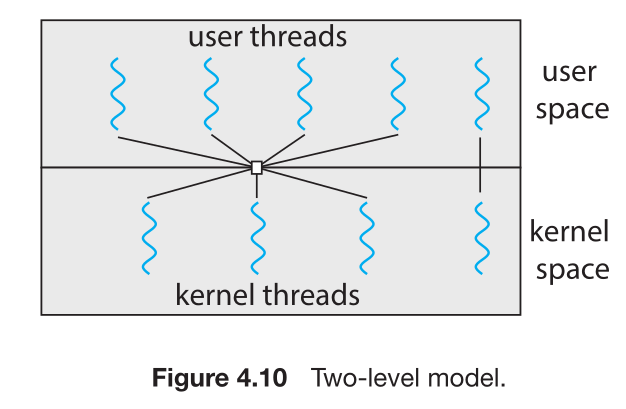

#### **Modern Context and Implementation**

The text makes two critical points about the modern relevance of these models:

1. **Implementation Difficulty:** The many-to-many and two-level models are complex to implement correctly in the operating system kernel.
2. **Shift to the One-to-One Model:** With the proliferation of multicore systems, the primary advantage of the many-to-many model—limiting kernel threads to save resources—has become less important. The hardware can now support many kernel threads running in parallel. Consequently, most modern general-purpose operating systems (**Windows, Linux, macOS**) have standardized on the simpler and high-performance **one-to-one model**.

However, the *concept* of the many-to-many model is experiencing a resurgence at the **library level**. Modern concurrency frameworks (like Java's `ExecutorService` or the Grand Central Dispatch system in Apple's ecosystems) allow programmers to define many "tasks." The library then manages a pool of worker threads (the kernel threads in a one-to-one system) to execute these tasks, effectively implementing the many-to-many model's logic in user space.

## **4.4 Thread Libraries**

A **thread library** is an Application Programming Interface (API) that provides programmers with a set of functions to create, manage, and synchronize threads.

#### **Implementation Methods**

There are two primary ways to implement a thread library, which correspond directly to the user and kernel thread concepts from the previous section:

1. **User-level Thread Library:**
   - The entire library—all code and data structures—exists in **user space**.
   - **How it works:** When your program calls a thread function (like `pthread_create()`), it is a **local function call** within your process. It does not require a system call to the kernel.
   - **Implication:** This is very fast and efficient, but it typically relies on the many-to-one model, meaning a blocking call by one thread will block the entire process.
2. **Kernel-level Thread Library:**
   - The library is implemented and supported directly by the **operating system kernel**.
   - **How it works:** When your program calls a thread function, it triggers a **system call** into the kernel.
   - **Implication:** This has more overhead than a user-level call but allows the OS to manage the threads directly, enabling true parallelism and preventing one thread from blocking the entire process. This is the model used by modern one-to-one systems.

#### **Major Thread Libraries in Use**

The text introduces three main thread libraries:

- **POSIX Pthreads:** A standardized threading interface for UNIX-like systems (Linux, macOS). It can be implemented as either a user-level or a kernel-level library.
- **Windows Threads:** The kernel-level threading API for the Windows operating system.
- **Java Threads:** The threading API provided by the Java programming language. Since the Java Virtual Machine (JVM) runs on a host OS, Java threads are ultimately implemented using the native thread library of that host system (e.g., Pthreads on Linux, Windows threads on Windows).

**A Key Difference in Data Sharing:**

- In **Pthreads and Windows**, any variable declared globally (outside of any function) is automatically **shared by all threads** in the process.
- In **Java**, there is no direct concept of global data. Sharing data between threads must be done explicitly, typically by having threads reference the same shared object.

#### **Thread Creation Strategies: Asynchronous vs. Synchronous**

Before looking at code examples, it's important to understand the two general strategies for how a parent thread manages its child threads.

**1. Asynchronous Threading**

- **Behavior:** The parent thread creates a child thread and then **immediately continues its own execution**. The parent and child run **concurrently and independently**.
- **Data Sharing:** There is typically little to no data sharing between the threads.
- **Use Cases:**
  - The **multithreaded server** from **Figure 4.2**, where the main thread immediately goes back to listening for new requests.
  - **Responsive user interfaces**, where a background thread handles a long task while the UI thread remains interactive.

**2. Synchronous Threading**

- **Behavior:** The parent thread creates one or more children and then **must wait for all of them to finish their work and terminate** before it can resume its own execution. This waiting for a thread to finish is often called **joining**.
- **Data Sharing:** This model often involves significant data sharing. The parent thread frequently needs to collect and combine the results computed by its children.
- **Use Case:** The upcoming summation example uses this strategy. The main thread will create a worker thread to calculate the sum, wait for it to finish, and then use the result.

The text states that all the following code examples for Pthreads, Windows, and Java will use the **synchronous threading** strategy.

### **4.4.1 Pthreads**

Pthreads is a standardized specification (IEEE 1003.1c) for an API to create and manage threads. It is a *specification*, not an implementation, meaning different operating systems can implement it as they see fit, but they must provide the same core functions. It is commonly found on UNIX-type systems like Linux and macOS.

#### **Program Walkthrough**

**1. Includes and Global Data**

```
#include <pthread.h>
#include <stdio.h>
#include <stdlib.h>

int sum; /* this data is shared by the thread(s) */
void *runner(void *param); /* threads call this function */
```

- `pthread.h` is the essential header for all Pthreads functions and data types.
- `int sum;` is a **global variable**. In Pthreads (and C), global data is automatically **shared by all threads** in the process. This is the variable where the child thread will store its result.

**2. Main Function - The Parent Thread**

```
int main(int argc, char *argv[])
{
    pthread_t tid; /* the thread identifier */
    pthread_attr_t attr; /* set of thread attributes */
```

- `pthread_t tid;` declares a variable to hold the unique **Thread ID**.
- `pthread_attr_t attr;` declares a structure to hold thread **attributes** (like stack size, scheduling policy). We will use the defaults.

**3. Initialization and Thread Creation**

```
    pthread_attr_init(&attr); /* set the default attributes */
    pthread_create(&tid, &attr, runner, argv[1]); /* create the thread */
```

- `pthread_attr_init(&attr)` initializes the attribute structure with default values.
- `pthread_create()` is the crucial call that **creates the new thread**. It takes four arguments:
  1. `&tid`: A pointer to the thread ID variable, which will be filled in by the system.
  2. `&attr`: A pointer to the thread attributes.
  3. `runner`: The name of the **function** where the new thread will start execution.
  4. `argv[1]`: The argument to pass to the `runner` function. In this case, it's the command-line argument (the number to sum up to).

**At this point, two threads are running concurrently:**

- The **main/parent thread** continues executing in the `main()` function.
- The **child thread** begins executing in the `runner()` function.

**4. Synchronous Join**

```
    pthread_join(tid, NULL); /* wait for the thread to exit */
    printf("sum = %d\n", sum);
```

- `pthread_join(tid, NULL)` is how the parent thread performs a **synchronous wait**. The `main` thread will block here until the child thread with ID `tid` terminates.
- This ensures that the `printf` statement does not execute until *after* the child thread has finished calculating the `sum`.

**5. The Runner Function - The Child Thread**

```
void *runner(void *param)
{
    int i, upper = atoi(param);
    sum = 0;
    for (i = 1; i <= upper; i++)
        sum += i;
    pthread_exit(0);
}
```

- This is the function the child thread executes. Its signature must be `void *func_name(void *param)`.
- `atoi(param)` converts the command-line string argument (`argv[1]`) passed from `main()` into an integer.
- The `for` loop performs the summation and stores the result in the **shared global variable** `sum`.
- `pthread_exit(0)` is how a thread explicitly terminates itself. The `0` is an exit status that could be retrieved by `pthread_join`.

#### **Joining Multiple Threads**

```
#define NUM_THREADS 10
pthread_t workers[NUM_THREADS]; /* an array of thread IDs */

/* ... Code to create 10 threads using pthread_create ... */

/* Wait for all 10 threads to finish */
for (int i = 0; i < NUM_THREADS; i++)
    pthread_join(workers[i], NULL);
```

This loop ensures the parent thread waits for all ten child threads to complete before it continues, which is essential for collecting all their results or performing a final aggregation.

### **4.4.2 Windows Threads**

#### **Program Walkthrough**

**1. Includes and Global Data**

```
#include <windows.h>
#include <stdio.h>

DWORD Sum; /* data is shared by the thread(s) */
```

- `windows.h` is the essential header file for the Windows API.
- `DWORD Sum;` is a global variable. `DWORD` is a Windows-specific data type for a 32-bit unsigned integer. As in Pthreads, global data is automatically **shared by all threads**.

**2. The Thread Function**

```
DWORD WINAPI Summation(LPVOID Param)
{
    DWORD Upper = *(DWORD*)Param;
    for (DWORD i = 1; i <= Upper; i++)
        Sum += i;
    return 0;
}
```

- The function that the new thread will run must have this specific signature: `DWORD WINAPI func_name(LPVOID Param)`.
  - `DWORD` is the return type.
  - `WINAPI` is a calling convention specific to the Windows API.
  - `LPVOID Param` is a pointer to a void, allowing any data type to be passed to the thread.
- `DWORD Upper = *(DWORD*)Param;` This line casts the `LPVOID` parameter back into a pointer to a `DWORD` and then dereferences it to get the integer value.
- The function calculates the sum and stores it in the shared global variable `Sum`.
- It terminates by `return 0;`, which is equivalent to `pthread_exit(0)`.

**3. Main Function - The Parent Thread**

```
int main(int argc, char *argv[])
{
    DWORD ThreadId;
    HANDLE ThreadHandle;
    int Param;
```

- `DWORD ThreadId;` will store the unique ID assigned to the new thread by the system.
- `HANDLE ThreadHandle;` This is a crucial concept. A **HANDLE** is an abstract reference to a kernel object—in this case, the thread. We use the handle to manage the thread.
- `int Param;` is a local variable to hold the command-line argument converted to an integer.

**4. Thread Creation**

```
    Param = atoi(argv[1]);
    ThreadHandle = CreateThread(
        NULL,                   /* default security attributes */
        0,                      /* default stack size */
        Summation,              /* thread function */
        &Param,                 /* parameter to thread function */
        0,                      /* default creation flags */
        &ThreadId);             /* returns the thread identifier */
```

- `CreateThread()` is the function that creates the new thread. Its parameters are:
  1. **Security Attributes:** `NULL` for default. Controls if child processes can inherit this handle.
  2. **Stack Size:** `0` for the default stack size (typically 1 MB).
  3. **Start Function:** `Summation`, the function the thread will execute.
  4. **Parameter:** `&Param`, a pointer to the data we want to pass to the `Summation` function.
  5. **Creation Flags:** `0` means the thread runs immediately after creation. `CREATE_SUSPENDED` would create it in a paused state.
  6. **Thread ID:** `&ThreadId`, a pointer to where the system should store the new thread's ID.

**5. Synchronous Join**

```
    WaitForSingleObject(ThreadHandle, INFINITE);
    CloseHandle(ThreadHandle);
    printf("sum = %d\n", Sum);
```

- `WaitForSingleObject(ThreadHandle, INFINITE)` is the Windows equivalent of `pthread_join()`.
  - It makes the parent thread block (wait) until the kernel object referred to by `ThreadHandle` (the child thread) enters a "signaled" state (which happens when the thread terminates).
  - `INFINITE` means the parent will wait forever if necessary.
- `CloseHandle(ThreadHandle)` is critical for resource management. Once you are done with a kernel object, you must close its handle to free system resources. The thread itself continues to run if it hasn't already finished.

#### **Waiting for Multiple Threads**

The text explains that to wait for multiple threads, you use `WaitForMultipleObjects()`.

**Example:**

```
// Assume THandles is an array of HANDLEs of size N
WaitForMultipleObjects(
    N,          // Number of objects (threads) to wait for
    THandles,   // Array of HANDLEs
    TRUE,       // Wait for ALL objects to be signaled (FALSE = wait for ANY)
    INFINITE    // Timeout duration (INFINITE to wait forever)
);
```

This function allows the parent thread to wait for an entire pool of worker threads to finish their work before proceeding, which is essential for synchronous execution patterns.

### **4.4.3 Java Threads**

Threads are a fundamental part of the Java language, and the Java API provides extensive features for creating and managing them. Every Java program, even a simple one with just a `main()` method, runs as a single thread within the Java Virtual Machine (JVM). The JVM then uses the host operating system's native thread library (e.g., Pthreads on Linux, Windows threads on Windows) to implement these Java threads.

#### **Two Techniques for Creating Threads**

Java provides two primary ways to create a thread. The more modern and commonly used technique is to implement the `Runnable` interface.

**1. Implement the `Runnable` Interface (Common Practice)** This involves creating a class that implements the `Runnable` interface, which requires defining a single method: `public void run()`.

```
class Task implements Runnable {
    public void run() {
        System.out.println("I am a thread.");
    }
}
```

The code inside the `run()` method is the task that will execute in a separate thread.

**2. Extend the `Thread` Class (Less Common)** The alternative is to create a new class that is derived from the `Thread` class and override its `run()` method.

#### **Thread Creation and Execution**

Once you have a `Runnable` object, you create and start a thread like this:

```
Thread worker = new Thread(new Task()); // Create a Thread object, passing a Runnable
worker.start(); // Start the thread
```

The `start()` method is crucial. It does two things:

1. It allocates memory and initializes a new thread within the JVM.
2. It automatically calls the `run()` method on your `Runnable` object, making the thread eligible to be scheduled by the JVM.

**Important:** You should never call the `run()` method directly. Calling `run()` directly would simply execute the method in the *current* thread, like a normal function call. You must use `start()` to launch a new thread of execution.

#### **Modern Syntax: Lambda Expressions**

Starting with Java 8, **Lambda expressions** provide a much more concise way to create threads, eliminating the need for a separate class. A Lambda expression effectively defines an anonymous `Runnable`.

```
Runnable task = () -> {
    System.out.println("I am a thread.");
};
Thread worker = new Thread(task);
worker.start();
```

This is functionally identical to the first example but is written in a cleaner, more compact style. Lambda expressions are a key feature for writing modern, readable concurrent code in Java.

#### **Synchronous Joining in Java**

To implement the synchronous threading strategy (where the parent thread waits for the child to finish), Java provides the `join()` method.

```
try {
    worker.join(); // Main thread waits here for 'worker' thread to finish
}
catch (InterruptedException ie) { }
```

- The `join()` method causes the current thread (e.g., the `main` thread) to block until the thread it is called on (`worker`) terminates.
- It can throw an `InterruptedException` if the waiting thread is interrupted, which must be caught or declared.

**Waiting for Multiple Threads:** Just like in Pthreads, you can wait for multiple threads by storing their references and joining them in a loop.

```
Thread[] workers = new Thread[10];
// ... Code to create and start 10 threads ...

// Wait for all 10 threads to finish
for (int i = 0; i < workers.length; i++) {
    try {
        workers[i].join();
    } catch (InterruptedException ie) { }
}
```

This pattern ensures the parent thread does not proceed until all child threads have completed their work, which is essential for collecting results.

### **4.4.3.1 Java Executor Framework**

The basic `Thread` and `Runnable` approach has been in Java since the beginning. However, Java 5 introduced a more powerful and flexible framework for concurrency in the `java.util.concurrent` package. The **Executor Framework** provides better control over thread creation, execution, and communication.

#### **Core Concept: Separating Task from Execution**

The fundamental idea is to separate *what* needs to be done (the task) from *how* it is run (the mechanics of thread management).

**The Executor Interface:** At the heart of the framework is the `Executor` interface:

```
public interface Executor {
    void execute(Runnable command);
}
```

Instead of creating a `Thread` object and calling `start()`, you now create an `Executor` and call `execute()` with your `Runnable` task.

```
Executor service = new SomeExecutorImplementation();
service.execute(new Task()); // Task is a class implementing Runnable
```

This design is based on the **producer-consumer model**: your application produces tasks (`Runnable` objects), and the threads managed by the `Executor` consume and execute them.

#### **Solving the Data Sharing Problem: Callable and Future**

In Pthreads and Windows, sharing results is easy with global variables. Java, being a pure object-oriented language, has no global data. The basic `Runnable` interface's `run()` method also cannot return a result.

The Executor Framework solves this with two key interfaces:

1. **`Callable<V>` Interface:**
   - Similar to `Runnable`, but its `call()` method can return a value and throw checked exceptions.
   - `V` is the type of the result returned by the task.
2. **`Future<V>` Interface:**
   - Represents the **result of an asynchronous computation** (a task that is running in another thread).
   - You use a `Future` object to retrieve the result *after* the task has completed.

#### **Program Walkthrough (Figure 4.14)**

The provided Java program demonstrates the Executor Framework with `Callable` and `Future`.

**1. The Summation Task (Callable)**

```
class Summation implements Callable<Integer> {
    private int upper;
    public Summation(int upper) {
        this.upper = upper;
    }
    public Integer call() {
        int sum = 0;
        for (int i = 1; i <= upper; i++)
            sum += i;
        return new Integer(sum); // This is the key: returning a result
    }
}
```

- The `Summation` class implements `Callable<Integer>`, meaning its `call()` method will return an `Integer`.
- The upper bound for the summation is passed via the constructor.
- The `call()` method performs the calculation and **returns the result**.

**2. The Main Driver (Using the Executor)**

```
public class Driver {
    public static void main(String[] args) {
        int upper = Integer.parseInt(args[0]);
        // Step 1: Create an ExecutorService (a thread pool with one thread)
        ExecutorService pool = Executors.newSingleThreadExecutor();

        // Step 2: Submit the Callable task to the executor. This returns a Future.
        Future<Integer> result = pool.submit(new Summation(upper));

        try {
            // Step 3: Retrieve the result using Future.get()
            System.out.println("sum = " + result.get());
        } catch (InterruptedException | ExecutionException ie) { }
    }
}
```

- `Executors.newSingleThreadExecutor()` creates an `ExecutorService` (a type of `Executor`) that uses a single worker thread.
- `pool.submit()` is used to submit a `Callable` task. It immediately returns a `Future<Integer>` object. This object is a *promise* of a future result; the calculation is now running in the background.
- `result.get()` is the equivalent of `join()`, but with a crucial difference: it **retrieves the result**. This method blocks the main thread until the computation is complete and then returns the `Integer` result produced by the `call()` method.

#### **Benefits of the Executor Framework**

While it seems more complex than `new Thread().start()`, the Executor Framework provides significant advantages:

1. **Returning Results:** `Callable` and `Future` allow threads to return values, which is not possible with basic `Runnable`.
2. **Decoupling:** It cleanly separates task submission from task execution. You focus on defining the task, and the framework handles the threading details.
3. **Efficiency and Control:** In Section 4.5.1, you will see that `ExecutorService` can manage a **pool of reusable threads**, which is far more efficient than creating and destroying a new thread for every single task. This is essential for managing a large number of tasks.

## **4.5 Implicit Threading**

As multicore processors become standard, applications are being designed with hundreds or even thousands of threads. Managing this level of concurrency explicitly is very difficult and error-prone, especially concerning the challenges of correctness (like race conditions and deadlocks, covered in Chapters 6 and 8).

#### **The Core Idea of Implicit Threading**

**Implicit threading** is a strategy to address this complexity. The core idea is to transfer the responsibility for creating and managing threads **from the application developer to the compiler and run-time libraries**.

**How it Works:** Instead of the programmer explicitly creating `Thread` objects and managing their lifecycle, they simply identify units of work, or **tasks**, that can run in parallel. These tasks are typically written as simple functions. A run-time library then takes these tasks and automatically maps them to a pool of threads, handling all the complex details of thread creation, scheduling, synchronization, and destruction.

**The Advantage:** The programmer only needs to think about **what** can be done in parallel (the tasks). The system handles **how** to execute them in parallel (the threading). This significantly reduces the potential for bugs and simplifies development.

#### **The JVM and the Host Operating System**

This note clarifies how Java threads, which we've been discussing, are actually implemented, linking back to the multithreading models from Section 4.3.

- The Java Virtual Machine (JVM) runs as an application on top of a host operating system (like Windows, Linux, or macOS).
- The JVM specification is abstract; it does not dictate how Java threads must be mapped to the OS. This decision is left to the specific JVM implementation.
- On operating systems like **Windows, Linux, and macOS** that use the **one-to-one model**, each Java thread is typically mapped directly to a kernel thread.
- Furthermore, the JVM implementation will use the host OS's native thread library to create these kernel threads (e.g., the Windows API on Windows, Pthreads on Linux/macOS).

This abstraction is what allows Java to be "write once, run anywhere." The same Java thread code works correctly regardless of the underlying OS threading implementation.

#### **The Shift in Programming Paradigm**

Implicit threading represents a fundamental shift:

- **Explicit Threading (Old Way):** Programmer manages `Thread` objects, `start()`, `join()`, etc.
- **Implicit Threading (New Way):** Programmer defines `Task` objects or functions. A library (like the Java Executor Framework) manages everything else.

The text states that implicit threading libraries typically use a threading model similar to the **many-to-many model**, where a pool of kernel threads is used to execute a potentially larger number of logical tasks defined by the programmer.

The following sections will explore four specific approaches to implicit threading.

### **4.5.1 Thread Pools**

A thread pool is a classic and powerful implementation of implicit threading. It directly addresses the performance and resource management problems of the "thread-per-request" model.

#### **The Problem with Unlimited Thread Creation**

Recall the multithreaded server from Section 4.1. While better than creating a process for each request, creating a new thread for every single request has two major drawbacks:

1. **Performance Overhead:** The time it takes to create and later destroy a thread is significant. For a high-traffic server, this constant creation and destruction of threads wastes CPU cycles and memory.
2. **Resource Exhaustion:** If the server receives a massive number of concurrent requests, it will create a correspondingly massive number of threads. This can exhaust system resources like CPU time and memory, potentially crashing the server.

#### **How a Thread Pool Works**

The thread pool pattern provides a solution:

- **At startup,** a fixed number of threads are created and placed into a "pool," where they sit idle, waiting for work.
- **When a request arrives,** it is submitted to the pool as a task (a `Runnable` or `Callable` in Java). The server does *not* create a new thread.
- **An available thread** from the pool is awakened and assigned the task. If no threads are available, the task waits in a queue until one becomes free.
- **When a thread finishes its task,** it does not terminate. Instead, it returns to the pool, ready to accept the next task.

**Refer to the Android Note:** The text highlights that Android's RPC system uses a thread pool for its remote services, allowing them to handle multiple concurrent client requests efficiently.

#### **Benefits of Thread Pools**

1. **Performance:** Using an existing thread from a pool is much faster than creating a new thread from scratch.
2. **Resource Control:** The pool places a strict bound on the number of concurrent threads, preventing the system from being overwhelmed. This is crucial for system stability.
3. **Flexibility:** It separates the task from the execution mechanics. This allows for advanced features like scheduling tasks for delayed or periodic execution.

**Tuning the Pool:** The number of threads in the pool can be set based on system factors (number of CPUs, memory) and expected load. More sophisticated pools can even resize themselves dynamically, using more threads under high load and fewer under low load to save resources.

#### **Thread Pools in Practice: Windows API Example**

The text provides an example using the Windows API to show how a programmer interacts with a thread pool.

**1. Define the Task Function:** This function is the code that will run in a pooled thread.

```
DWORD WINAPI PoolFunction(PVOID Param) {
    /* this function runs as a separate thread from the pool. */
}
```

**2. Submit the Task to the Pool:** Instead of using `CreateThread()`, the program uses `QueueUserWorkItem()` to submit the task.

```
QueueUserWorkItem(&PoolFunction, NULL, 0);
```

This function's parameters are:

- `&PoolFunction`: A pointer to the function to execute.
- `NULL`: The parameter to pass to the function (none in this case).
- `0`: Flags for special instructions (none in this case).

The Windows thread pool API is extensive, also providing utilities to run functions after a timer expires or when an I/O operation completes. This demonstrates the power and flexibility of letting a library handle the threading details.

#### **4.5.1.1 Java Thread Pools**

The Java Executor Framework, introduced earlier, is the primary mechanism for creating and managing thread pools. It provides several pre-configured pool architectures through factory methods in the `Executors` class.

##### **Three Common Thread Pool Models**

Java's `java.util.concurrent` package offers several types of thread pools. The text focuses on three core models:

1. **Single Thread Executor (`newSingleThreadExecutor()`):**
   - Creates a pool with **exactly one thread**.
   - All submitted tasks are executed sequentially by this single thread.
   - Useful for tasks that need to be processed in a strict order without concurrency.
2. **Fixed Thread Executor (`newFixedThreadPool(int size)`):**
   - Creates a pool with a **fixed number of threads**.
   - This is the most common pool for controlling resource usage. The number of concurrent tasks is strictly limited to the pool size; extra tasks wait in a queue.
   - Ideal for known, sustained workloads (e.g., a server with a predictable number of concurrent requests).
3. **Cached Thread Executor (`newCachedThreadPool()`):**
   - Creates an "unbounded" pool that can create new threads as needed, but will **reuse idle existing threads**.
   - If a thread is idle for 60 seconds, it is terminated and removed from the pool.
   - This pool improves performance for many short-lived asynchronous tasks but is dangerous for unbounded workloads as it could create thousands of threads.

##### **Creating and Using a Thread Pool (Figure 4.15)**

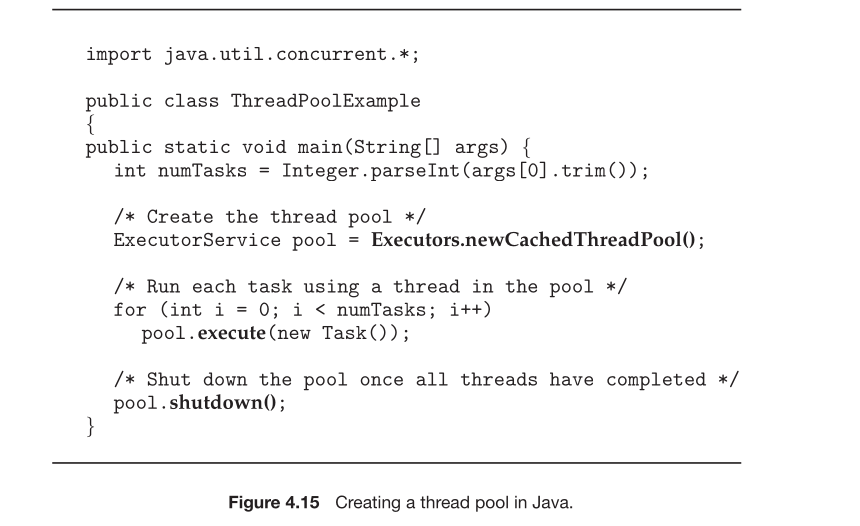

The Java program in **Figure 4.15** demonstrates the standard pattern for using a thread pool.

**1. Create the Thread Pool:**

```
ExecutorService pool = Executors.newCachedThreadPool();
```

This line uses a factory method to create and return an `ExecutorService` instance—in this case, a cached thread pool.

**2. Submit Tasks to the Pool:**

```
for (int i = 0; i < numTasks; i++)
    pool.execute(new Task()); // 'Task' is a class implementing Runnable
```

- The `execute(Runnable command)` method is used to submit tasks to the pool.
- The pool manages the internal queue and assigns each task to an available thread from the pool. The programmer does not create any `Thread` objects.

**3. Shut Down the Pool:**

```
pool.shutdown();
```

- The `shutdown()` method is crucial for graceful termination.
- It tells the executor to stop accepting new tasks.
- The pool will then shut down *after* all previously submitted tasks have finished executing.
- (There is also a `shutdownNow()` method which attempts to stop all actively executing tasks.)

##### **Key Concepts Recap**

- **`ExecutorService` Interface:** This is the core interface you work with. It extends the basic `Executor` interface and adds life-cycle management methods like `submit()`, `shutdown()`, and `awaitTermination()`.
- **Implicit Threading in Action:** This is a perfect example of implicit threading. The programmer defines `Task` objects (the *what*) and submits them to the `ExecutorService`. The framework handles all the details of thread creation, lifecycle, and assignment (the *how*). This makes the application more robust, efficient, and easier to write correctly.

### **4.5.2 Fork-Join**

The fork-join paradigm is a specific strategy for parallel programming that is exceptionally well-suited for implicit threading.

#### **Recap: The Explicit Fork-Join Model**

As covered in Section 4.4, the basic idea is:

1. **Fork:** A parent thread **creates (forks)** one or more child threads to perform subtasks.
2. **Work:** The parent and children work concurrently.
3. **Join:** The parent **waits (joins)** for all child threads to finish.
4. **Combine:** The parent combines the results from the children.

This is the **synchronous threading** strategy we saw in the Pthreads, Windows, and basic Java examples.

#### **The Implicit Fork-Join Model**

The implicit threading approach takes this same logical pattern but removes the burden of thread management from the programmer.

**How it Works:**

- Instead of explicitly creating `Thread` objects, the programmer only identifies **parallel tasks** that can be forked.
- A sophisticated run-time library is responsible for:
  - Creating and managing the actual threads.
  - Deciding how many threads to create (e.g., based on the number of CPU cores).
  - Assigning the forked tasks to these threads.
  - Handling the joining and result combination.

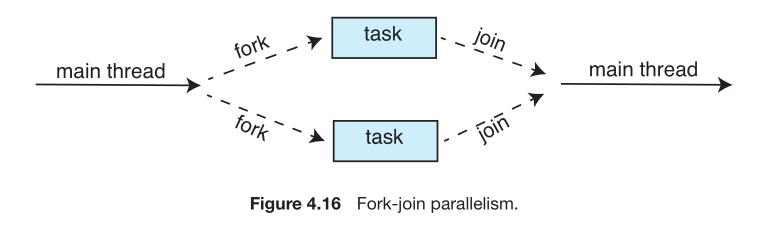

#### **Relationship to Thread Pools**

The text describes the implicit fork-join model as a **"synchronous version of thread pools."**

- **Standard Thread Pool (Asynchronous):** You submit independent tasks (like in the web server), and you don't necessarily wait for them to finish in a specific order.
- **Fork-Join Pool (Synchronous):** The pool is used to execute tasks that have explicit dependencies—a parent task cannot finish until its children tasks have completed and returned their results. The library manages the complex scheduling required to efficiently execute these interdependent tasks.

The library uses smart heuristics (like the number of available cores) to determine the optimal number of threads, ensuring efficient use of system resources without over-subscription.

In summary, the fork-join pattern is a powerful parallel algorithm design. Using an implicit threading library to implement it allows developers to express the parallel logic clearly while the library handles the complex and error-prone details of thread synchronization and workload balancing. This is especially effective for problems that can be broken down recursively, like sorting or tree traversal.

#### **4.5.2.1 Fork Join in Java**

##### **What is the Fork-Join Framework?**

The fork-join framework is a Java library (added in Java 7) designed specifically for a common type of parallel programming problem: **recursive divide-and-conquer algorithms**. If you think of algorithms like Quicksort or Mergesort, they perfectly fit this model. The core idea is simple: you break a big problem down into smaller sub-problems, solve those sub-problems concurrently, and then combine the results.

##### **The General Recursive Algorithm**

The framework operates on a simple, recursive pattern. Every task you create follows this logical structure:

```
Task(problem)
    if problem is small enough
        solve the problem directly  // This is the "base case"
    else
        subtask1 = fork(new Task(subset of problem))  // Split off a new task to be run in parallel
        subtask2 = fork(new Task(subset of problem))  // Split off another task
        result1 = join(subtask1)  // Wait for the first subtask's result
        result2 = join(subtask2)  // Wait for the second subtask's result
        return combined results    // Merge the results from the subtasks
```

- **Fork:** The `fork()` method is used to start a new task (a new piece of work) asynchronously. It's like telling a helper thread, "Go start working on this sub-problem."
- **Join:** The `join()` method is used to get the result of a forked task. This call will **block** (wait) until the result from that specific subtask is ready.
- **Base Case:** This is the condition that stops the recursion. When the problem becomes small enough, it's more efficient to solve it directly in the current thread rather than paying the overhead of creating new tasks.

*(You should refer to Figure 4.17 in your textbook for a graphical depiction of this forking and joining process.)*

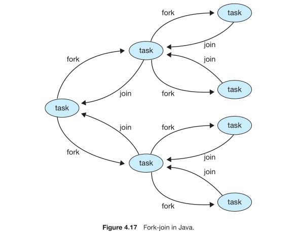

##### **A Concrete Example: Summing an Array**

Let's make this concrete by designing a program that sums all the elements in a large array of integers using the fork-join framework.

**Step 1: Set up the Thread Pool and Initial Task**

First, you create a special thread pool called a `ForkJoinPool`. This pool is smart and manages the worker threads that will execute your tasks. You then create the initial, "root" task that represents the entire problem and submit it to the pool.

```
ForkJoinPool pool = new ForkJoinPool();
int[] array = new int[SIZE]; // This array contains the integers to be summed
SumTask task = new SumTask(0, SIZE - 1, array); // The task to sum the whole array
int sum = pool.invoke(task); // Submit the task and get the final result
```

The `invoke()` method submits the task and waits for its completion, returning the final sum.

**Step 2: Define the Task (`SumTask`)**

The real work happens inside the `SumTask` class. This class must define *what* the task does in its `compute()` method.

*(You should refer to Figure 4.18 in your textbook for the full code listing of the `SumTask` class.)*

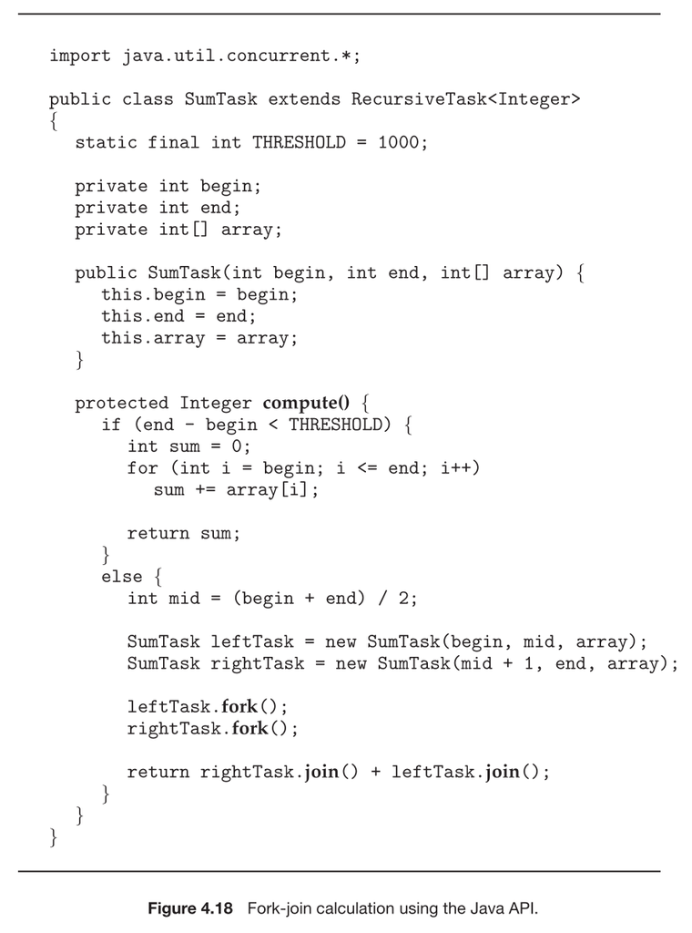

##### **Key Classes in the Fork-Join Framework**

The framework is organized around a few key classes, as shown in the UML diagram in *(Figure 4.19)*:

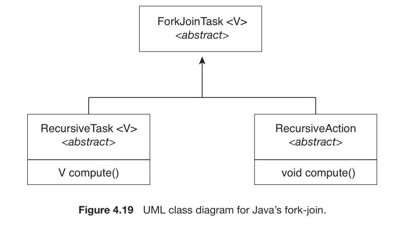

- **`ForkJoinTask<V>`:** This is the abstract base class for all tasks.
- **`RecursiveTask<V>`:** You extend this class when your task **returns a result** (like our `SumTask` which returns an `Integer`). You must override the `compute()` method.
- **`RecursiveAction`:** You extend this class when your task does **not return a result** (e.g., a task that sorts an array in-place). You also override the `compute()` method here.

##### **Important Considerations**

- **Choosing the Threshold (`THRESHOLD`):** Deciding when a problem is "small enough" is critical. If the threshold is too high, you don't get enough parallelism. If it's too low, the overhead of creating and managing tasks outweighs the benefits of parallel execution. The textbook notes that finding the optimal value often requires careful experimentation and timing trials.
- **Work Stealing:** This is the "magic" that makes the `ForkJoinPool` so efficient. Each thread in the pool has its own double-ended queue (deque) of tasks. When a thread forks a new task, it pushes it onto its own deque. When a thread is ready for more work, it pops a task from the *head* of its own deque. The key innovation is that if a thread's deque is empty, it can "steal" a task from the *tail* of another thread's deque. This **work-stealing algorithm** efficiently balances the load across all threads, ensuring that no thread is idle while others have work.

### **4.5.3 OpenMP**

#### **What is OpenMP?**

OpenMP is a powerful tool for parallel programming in **shared-memory environments**, used with C, C++, and FORTRAN. It works through a combination of **compiler directives** (special commands in your code) and an API library. The main goal of OpenMP is to make it easier to take parts of a program that can run at the same time and actually make them run in parallel, without the programmer having to manually create and manage threads.

#### **The Core Concept: Parallel Regions**

The fundamental idea in OpenMP is the **parallel region**. This is a block of code that is marked to be executed by multiple threads simultaneously.

Here is a simple C program that demonstrates this:

```
#include <omp.h>
#include <stdio.h>

int main(int argc, char *argv[])
{
    /* sequential code */ // This runs once, on the main thread.

    #pragma omp parallel
    {
        printf("I am a parallel region.\n");
    }

    /* sequential code */ // This also runs once, after the parallel region.
    return 0;
}
```

Let's break down what happens:

1. The program starts running sequentially (with a single thread).
2. When it encounters the **`#pragma omp parallel`** directive, the OpenMP run-time library springs into action.
3. It creates a **team of threads**. By default, it creates **one thread for each processing core** in your system.
   - On a dual-core system: 2 threads are created.
   - On a quad-core system: 4 threads are created.
4. **All of these threads then simultaneously execute the code block** that follows the directive. In this example, each thread will print "I am a parallel region." So, if you have 4 cores, you will see that message printed 4 times.
5. When a thread reaches the end of the block `}`, it terminates. The main thread (the original one) continues, and the program resumes its sequential execution.

#### **Parallelizing Loops**

A very common use for OpenMP is to speed up loops where each iteration is independent of the others. This is called a **parallel for loop**.

Consider this problem: you have two arrays, `a` and `b`, each of size `N`. You want to add them together and store the result in array `c`. The sequential way to do this is with a simple `for` loop.

With OpenMP, you can parallelize this loop with a single directive:

```
#pragma omp parallel for
for (int i = 0; i < N; i++) {
    c[i] = a[i] + b[i];
}
```

Here's what the **`#pragma omp parallel for`** directive does:

- It creates a team of threads (just like `omp parallel`).
- It then **automatically divides the iterations of the `for` loop** among these threads.
- For example, if you have 1000 iterations (`N=1000`) and 4 threads, OpenMP might assign iterations 0-249 to thread 1, 250-499 to thread 2, and so on. Each thread works on its assigned chunk of the array independently and in parallel.
- There is an implicit barrier at the end of the loop, meaning all threads must finish their assigned iterations before any thread can proceed to the code that follows.

#### **Key Features and Flexibility**

OpenMP is not just about basic parallelism; it gives developers fine-grained control:

- **Controlling the Number of Threads:** You are not stuck with the default. You can manually set the number of threads in your team using functions like `omp_set_num_threads()` or by setting environment variables.
- **Data Scoping:** This is a critical concept. OpenMP allows you to specify whether variables are **shared** between all threads or **private** to each thread.
  - In the loop example above, the arrays `a`, `b`, and `c` are typically shared (all threads need to read/write to them).
  - The loop index `i` is made **private** by the `parallel for` directive. This means each thread gets its own separate copy of `i`, so they don't interfere with each other's counting.
- **Wide Availability:** OpenMP is supported by many popular open-source and commercial compilers (like GCC, Clang, and MSVC) on Linux, Windows, and macOS.

In summary, OpenMP provides a high-level, relatively simple way to add parallelism to your code by using special directives that tell the compiler how to split the work across multiple threads in a shared-memory system.

### **4.5.4 Grand Central Dispatch**

#### **What is Grand Central Dispatch (GCD)?**

Grand Central Dispatch (GCD) is a technology developed by Apple for its macOS and iOS operating systems. It's a complete solution for managing parallel tasks, consisting of:

- A **run-time library**
- An **API** (Application Programming Interface)
- **Language extensions**

Its main goal is to simplify parallel programming. Like OpenMP, GCD handles the complex details of thread management, allowing you, the developer, to focus on *what* tasks can run in parallel, not *how* the threads are created and scheduled.

#### **The Core Mechanism: Dispatch Queues**

The central concept in GCD is the **dispatch queue**. You don't manage threads directly; instead, you define units of work (tasks) and place them into a queue. GCD's system then takes these tasks from the queue and schedules them to run on available threads from a pool it manages.

GCD has two fundamental types of queues:

**1. Serial Queues (Private Dispatch Queues)**

- Tasks are removed from the queue in a **First-In, First-Out (FIFO)** order.
- However, **only one task is executed at a time**. A task must completely finish before the next task in the queue is removed and started.
- **Characteristics:**
  - Each application has a special serial queue called the **main queue**, which is used for all updates to the user interface.
  - Developers can create their own serial queues for process-specific tasks.
  - They are perfect for ensuring that a series of tasks happens in a strict, predictable sequence, which is crucial for preventing race conditions when accessing shared resources.

**2. Concurrent Queues (Global Dispatch Queues)**

- Tasks are also removed in **FIFO** order.
- However, **multiple tasks can be removed at once**, allowing them to execute in parallel.
- The system provides several **system-wide concurrent queues** that you can use. These are categorized by **Quality of Service (QoS)** classes, which help the system prioritize your tasks intelligently.

#### **Quality of Service (QoS) Classes**

GCD uses QoS classes to determine the priority and resource allocation for tasks. This allows the system to ensure a responsive user experience while efficiently managing battery life. The four primary classes are, in order of priority:

- **QOS_CLASS_USER_INTERACTIVE:**
  - **Purpose:** For tasks that directly interact with the user to keep the interface responsive and smooth (e.g., animations, event handling).
  - **Workload:** Tasks should be very short and require minimal processing time.
- **QOS_CLASS_USER_INITIATED:**
  - **Purpose:** For tasks that the user has started and is waiting for, so they can continue interacting with the app (e.g., opening a document, processing a user's button press).
  - **Workload:** Can take longer than user-interactive tasks, but should still be completed in a few seconds or less.
- **QOS_CLASS_UTILITY:**
  - **Purpose:** For long-running tasks where the user does not expect immediate results (e.g., importing data, downloading a large file, complex calculations).
  - **Workload:** These are typically longer-running operations that provide a progress indicator.
- **QOS_CLASS_BACKGROUND:**
  - **Purpose:** For tasks that are not time-sensitive and the user is not directly aware of (e.g., indexing files, performing backups, pre-fetching content).
  - **Workload:** The system will schedule these tasks when resources are available, prioritizing the user's battery life.

#### **Defining Tasks: Blocks and Closures**

To submit work to a queue, you need to define the task. GCD provides two ways to do this, depending on the language:

1. **Blocks (C, C++, Objective-C):** A block is a language extension that defines a self-contained unit of work. It's syntax is a caret `^` followed by braces `{ }` containing the code.
   - **Example:** `^{ printf("I am a block"); }`
2. **Closures (Swift):** In Swift, the same concept is achieved using a **closure**. Syntactically, it is very similar to a block but without the leading caret.
   - **Example:** `{ print("I am a closure.") }`

#### **Putting It All Together: A Code Example**

The following Swift code shows how to obtain a concurrent queue and submit a task to it asynchronously.

```
// 1. Get a reference to a system-wide concurrent queue.
//    We specify the .userInitiated Quality of Service class.
let queue = DispatchQueue.global(qos: .userInitiated)

// 2. Submit a task (closure) to the queue to be executed asynchronously.
//    The dispatch async() function returns immediately, without waiting for the task to finish.
dispatchAsync(queue) {
    print("I am a closure running on a concurrent queue.")
}
```

#### **GCD Internals and Portability**

- **Under the Hood:** Internally, GCD's thread pool is implemented using **POSIX threads (Pthreads)**. GCD actively manages this pool, dynamically growing or shrinking the number of threads based on the current demand and the overall capacity of the system.
- **Portability:** While developed by Apple, the core library behind GCD (`libdispatch`) has been released as open-source and has been ported to other operating systems, such as **FreeBSD**.

### **4.5.5 Intel Threading Building Blocks (TBB)**

#### **What is Intel TBB?**

Intel Threading Building Blocks (TBB) is a sophisticated **C++ template library** designed to support the development of parallel applications. Its key advantage is that it is purely a library; it doesn't require a special compiler or language extensions. You use it by including its headers and linking to its library.

The core idea is that you, the developer, specify logical **tasks** that can run in parallel. The TBB **task scheduler** then takes over, managing the complex job of mapping these tasks onto the underlying physical threads (like Pthreads or Windows threads). This scheduler is very smart—it provides automatic **load balancing** and is **cache-aware**, meaning it tries to schedule tasks in a way that maximizes the use of data already in the CPU cache for faster execution.

#### **Key Features of TBB**

TBB provides a rich toolkit for parallel programming, including:

- **Templates for Parallel Algorithms:** Such as `parallel_for`, `parallel_reduce`, and `pipeline`, which let you easily parallelize common patterns.
- **Synchronization:** Support for atomic operations and mutual exclusion locks (mutexes).
- **Concurrent Data Structures:** Thread-safe versions of common data structures like a hash map, queue, and vector. These are designed for high performance in concurrent environments and can be used as safer alternatives to standard template library (STL) containers in multi-threaded code.

#### **A Core Example: The Parallel For Loop**

Let's explore the most common use case: parallelizing a simple loop.

Imagine you have a function `apply(float value)` that performs an operation on a single value. You also have an array `v` of size `n` containing float values. The sequential way to process this array is with a standard `for` loop:

```
// Sequential for loop
for (int i = 0; i < n; i++) {
    apply(v[i]);
}
```

To parallelize this on a multicore system, you could manually split the array into chunks and assign each chunk to a different thread. However, this approach is tedious and **hardcodes the parallelism to a specific number of cores**, making the code inflexible and non-portable.

TBB solves this with its **`parallel_for`** template. The general form is: `parallel_for(range, body)`

- **`range`:** Defines the set of items to be processed (the "iteration space").
- **`body`:** Defines the operation to be performed on a sub-range or individual items.

Here is how you would rewrite the sequential loop using TBB:

```
// Parallel for loop with TBB
tbb::parallel_for(size_t(0), n, [=](size_t i) { apply(v[i]); });
```

Let's break down the three parameters in this call:

1. **`size_t(0)`**: The start of the iteration space (index 0).
2. **`n`**: The end of the iteration space (index `n-1`). This defines that we want to iterate from `0` to `n-1`, just like the original loop.
3. **`[=](size_t i) { apply(v[i]); }`**: This is a **C++ lambda function** that acts as the loop body.
   - **`[=]`**: This is the *capture clause*. The equals sign means the lambda "captures" all variables from the outer scope *by value*. This means it gets its own copy of the array `v` and the size `n`, which is safe for parallel execution.
   - **`(size_t i)`**: This is the parameter. The TBB library will call this lambda function multiple times in parallel, each time passing a different index `i` from the iteration space (0 to n-1).
   - **`{ apply(v[i]); }`**: This is the body of the function, which executes for each index `i`.

#### **How TBB Manages the Work**

When you call `parallel_for`, TBB's internal machinery takes over:

1. **Dividing Work:** The library automatically divides the full range of iterations (0 to n-1) into smaller "chunks." You can specify the chunk size, but often the default is efficient.
2. **Creating Tasks:** It creates a set of tasks, where each task is responsible for executing the loop body (the lambda function) over one of these chunks.
3. **Scheduling on Threads:** The TBB task scheduler assigns these tasks to a pool of worker threads it manages. This is very similar to the Java Fork-Join framework. If one thread finishes its chunk early, the scheduler can give it another chunk from another thread (**work-stealing**), ensuring all threads stay busy and the load is balanced.

#### **Summary and Advantage**

The primary advantage of TBB is **abstraction**. You only need to identify *what* can run in parallel (by using constructs like `parallel_for`), and the library handles all the low-level details of thread creation, management, load balancing, and synchronization. This leads to code that is more portable, maintainable, and often performs better than a manual threading approach.

Intel TBB is available in both commercial and open-source versions and runs on all major operating systems: Windows, Linux, and macOS.

## **4.6 Threading Issues**

This section covers important complications that arise when using threads in real-world programs. The standard behavior of familiar system calls can change in a multithreaded environment, and programmers must be aware of these nuances.

### **4.6.1 The `fork()` and `exec()` System Calls**

As you learned in the Computer Architect course and Chapter 3, the `fork()` and `exec()` system calls are fundamental to process creation in UNIX/Linux systems. However, their semantics become more complex when the process performing the call contains multiple threads.

#### **The Problem with `fork()` in a Multithreaded Program**

The central question is: When a thread in a multithreaded process calls `fork()`, what does the new child process look like?

1. **Does it duplicate all threads?** The new child process could be an exact replica of the parent, with copies of all its threads.
2. **Or is it single-threaded?** The new process could contain only the thread that called the `fork()`.

Different UNIX systems have addressed this problem by providing **two versions of the `fork()` call**:

- One version that duplicates all threads of the parent process in the child.
- Another version that duplicates only the thread that invoked `fork()`.

#### **The Behavior of `exec()`**

The `exec()` system call behaves more predictably. If any thread in a process calls `exec()`, it works as described in Chapter 3: the program specified in the `exec()` call **completely replaces the current process**, including its code, data, heap, stack, and **all of its threads**. The new process starts from the `main()` function of the new program with a single thread.

#### **Choosing the Right `fork()` Semantics**

The choice between duplicating all threads or just one depends entirely on what the child process is intended to do immediately after the `fork()`.

- **Case 1: `fork()` is followed immediately by `exec()`**
  - **Scenario:** This is a common pattern where the goal is to create a new process to run a completely different program (e.g., a shell creating a new process to run `ls`).
  - **Appropriate `fork()` Semantics:** In this case, **duplicating only the calling thread is appropriate and efficient**. The child process is going to have its entire address space wiped away and replaced by the new program when `exec()` is called. Duplicating all the other threads from the parent would be a waste of effort, as they would be terminated instantly. It can also be dangerous if other threads are holding locks, as the locks would be copied into the child in a locked state and never unlocked (since the threads holding them don't exist), leading to deadlocks.
- **Case 2: `fork()` is *not* followed by `exec()`**
  - **Scenario:** The goal is to create a new child process that continues executing the same program, potentially to handle a task in parallel.
  - **Appropriate `fork()` Semantics:** Here, the child process needs to be a fully functional copy of the parent. Therefore, it **should duplicate all threads**. This allows the child to continue the parent's work using its entire parallel structure.

In summary, the correct use of `fork()` in a multithreaded program requires you to know the child's purpose and to use the version of `fork()` whose semantics match that purpose to ensure correctness and efficiency.

### **4.6.2 Signal Handling**

#### **What is a Signal?**

A **signal** is a software interrupt delivered to a process in UNIX/Linux systems, notifying it that a specific event has occurred. Signals can be categorized by how they are delivered:

- **Synchronous Signals:** These are generated by the process's own execution.
  - **Cause:** The event is a direct result of an action performed by the process's own code.
  - **Examples:** An illegal memory access (Segmentation Fault), division by zero, or executing an illegal instruction.
  - **Delivery:** They are delivered to the very thread that caused the event.
- **Asynchronous Signals:** These are generated by an event external to the process.
  - **Cause:** An event outside the running process.
  - **Examples:** A user pressing `Ctrl+C` to terminate a program (this sends the `SIGINT` signal), or a timer expiring.
  - **Delivery:** They are sent to the process from another process or the operating system.

#### **Handling a Signal**

When a signal is delivered, it must be processed. There are two types of handlers:

1. **Default Signal Handler:** Every signal has a default action defined by the kernel. For example, the default for `SIGSEGV` (segmentation fault) is to terminate the process. For `SIGCHLD` (child process stopped or terminated), the default is to ignore it.
2. **User-Defined Signal Handler:** A program can override the default action and specify its own function to be called when a specific signal arrives. This allows the program to perform custom cleanup or ignore the signal entirely.

#### **The Challenge: Where to Deliver a Signal in a Multithreaded Program?**

In a single-threaded program, this is simple: the one and only thread handles all signals. In a multithreaded program, it becomes a critical design question: which thread should receive the signal?

Several strategies exist:

1. **Deliver the signal to the thread to which the signal applies.** (Most logical for synchronous signals).
2. **Deliver the signal to every thread in the process.**
3. **Deliver the signal to certain threads in the process.**
4. **Assign a specific thread to receive all signals for the process.**

The correct strategy depends on the signal type:

- **For Synchronous Signals:** The signal **must be delivered to the thread that caused it**. It wouldn't make sense for a thread that performed a legal operation to be terminated because another thread in the same process caused a segmentation fault.
- **For Asynchronous Signals:** The strategy is less clear-cut and depends on the signal's intent.
  - A signal like `SIGTERM` (a request to terminate) is typically meant for the entire process, so it should be delivered to **all threads**.
  - Other asynchronous signals might be targeted. To manage this, POSIX threads (Pthreads) allows each thread to have its own **signal mask**, which it uses to specify which signals it will accept and which it will block.

#### **APIs for Signal Delivery**

- **Standard Process-Level Signal (`kill`):** The classic UNIX function `kill(pid_t pid, int signal)` sends a signal to a *process* (identified by `pid`). In a multithreaded environment, the system then decides which thread within that process will handle it. Typically, it will be delivered to the **first thread found that is not blocking that signal**.
- **Thread-Targeted Signal (`pthread_kill`):** Pthreads provides a more precise function: `pthread_kill(pthread_t tid, int signal)`. This allows a programmer to send a specific signal to a specific thread (identified by its thread ID, `tid`), giving fine-grained control over signal handling.

#### **Signal Handling in Windows**

Windows does not have a direct equivalent to UNIX signals. Instead, it provides **Asynchronous Procedure Calls (APCs)**.

- **How it Works:** An APC allows a thread to specify a function that should be called when that thread receives a particular notification. The APC is queued to the target thread, and the thread executes the function when it enters an "alertable" wait state.
- **Key Difference:** The APC model is more straightforward for threading because an APC is, by design, delivered to a **specific, single thread**. This avoids the ambiguity present in the UNIX multithreaded signal delivery model.

### **4.6.3 Thread Cancellation**

Thread cancellation is the process of terminating a thread before it has naturally finished its work. This is a common feature in multi-threaded programs where results can become obsolete, or a user changes their mind.

**Real-World Examples:**

- **Database Search:** Multiple threads search a database in parallel. As soon as one thread finds the result, the others are canceled to save CPU resources.
- **Web Browser:** A web page loads with multiple threads (one for the main HTML, one for each image). When you press the "Stop" button, the browser cancels all the threads that are still loading the page.

A thread that is scheduled for termination is called the **target thread**.

#### **The Two Scenarios for Cancellation**

There are two fundamental ways to cancel a thread, each with major implications for safety and resource management.

**1. Asynchronous Cancellation**

- **How it works:** One thread immediately and forcibly terminates the target thread.
- **The Major Problem:** This is dangerous. The target thread can be killed at any point in its execution, even if it is in the middle of a critical operation. Imagine canceling a thread that:
  - Has allocated memory (leading to a memory leak).
  - Is holding a lock (causing other threads to wait forever, a **deadlock**).
  - Is in the middle of updating a shared data structure (leaving it in a corrupted, inconsistent state).
- **Resource Reclamation:** The operating system will reclaim some system resources (like the thread's kernel data structures), but it often cannot reclaim all application-level resources (like memory, open files, or locks). Therefore, asynchronous cancellation is generally considered unsafe and is not recommended.

**2. Deferred Cancellation**

- **How it works:** The cancellation request is sent to the target thread, but the thread is not terminated immediately. Instead, the target thread periodically checks if a cancellation request is pending. When it sees the request, it terminates itself at a safe point in its code.
- **Why it's Better:** This allows the thread to be canceled when it is not in the middle of a critical operation. The thread can release any resources it holds (like freeing memory or unlocking mutexes) before it terminates, preventing leaks, deadlocks, and data corruption.

#### **Thread Cancellation in Pthreads**

In the Pthreads (POSIX threads) library, cancellation is initiated using the `pthread_cancel(tid)` function. However, calling this function only **requests** cancellation; it does not guarantee the thread will be terminated. The actual behavior depends on the target thread's configuration.

**Pthreads Cancellation Modes:**

A thread's cancellation behavior is controlled by a **state** and a **type**.

| Mode | State | Type |
| --- | --- | --- |
| Off | `Disabled` | -- |
| Deferred | `Enabled` | `Deferred` |
| Asynchronous | `Enabled` | `Asynchronous` |

- **State (`Disabled`/`Enabled`):** If cancellation is `Disabled`, the thread will ignore all cancellation requests (though they remain pending). The thread can later enable cancellation to act on them.
- **Type (`Deferred`/`Asynchronous`):** This determines how an enabled thread responds to a cancellation request. The **default type is `Deferred`**.

**How Deferred Cancellation Works in Code:**

A thread using deferred cancellation will only be terminated when it reaches a **cancellation point**. A cancellation point is a specific function call (usually a blocking system call) where it is safe to check for termination.

- Common cancellation points include `read()`, `write()`, `sleep()`, and `pthread_join()`. (You can see a full list on a Linux system with the command `man pthreads`).
- A thread can also create its own cancellation point by calling `pthread_testcancel()`. This function does nothing if there is no pending cancellation request. If there *is* a request, the function does not return, and the thread is terminated immediately at that point.

**Code Example of Deferred Cancellation:**

```
while (1) {
    /* do some work for awhile */
    ...

    /* check if there is a cancellation request */
    pthread_testcancel();
}
```

**Cleanup Handlers:** Pthreads allows a thread to register **cleanup handler** functions. These are functions that are automatically called if the thread is canceled. This is the primary mechanism for ensuring resources are properly released before the thread dies (e.g., to free memory or unlock a mutex).

**Important Note:** Due to the severe risks of resource leaks and data corruption, the Pthreads documentation strongly discourages the use of **asynchronous cancellation**. It is safer and more predictable to use deferred cancellation and manage resource cleanup properly.

**Implementation Note on Linux:** On Linux systems, the Pthreads library implements thread cancellation internally using **signals** (which were discussed in **Section 4.6.2**).

#### **Thread Cancellation in Java**

Java provides a mechanism for thread cancellation that follows a policy very similar to **deferred cancellation** in Pthreads. It is designed to be safer and more cooperative than forced termination.

##### **The Java Interruption Mechanism**

Instead of a direct `cancel` command, Java uses an **interruption** model.

- **Initiating Cancellation:** To request that a thread terminates, you call the `interrupt()` method on the `Thread` object.

  ```
  Thread worker;
  . . .
  // Set the interruption status of the thread
  worker.interrupt();
  ```

  This method does not forcibly stop the thread. Instead, it does two things:
  1. It sets the thread's **interruption status** to `true`.
  2. If the thread is currently blocked in a method like `sleep()`, `wait()`, or `join()`, that method will immediately throw an `InterruptedException`.
- **Checking for Cancellation:** The target thread is responsible for periodically checking if it has been interrupted and then cleaning up and terminating itself. This is the "cooperative" or "deferred" part.

  A thread can check its interruption status in a loop using the `isInterrupted()` method:

  ```
  while (!Thread.currentThread().isInterrupted()) {
      // Do some work
      . . .
  }
  // Once interrupted, break out of the loop and clean up
  ```

  When the `interrupt()` method is called, the `isInterrupted()` check becomes `true`, the loop condition fails, and the thread exits the loop. The thread can then release any resources and terminate gracefully.

##### **Handling Blocking Calls with `InterruptedException`**

A crucial part of Java's design is what happens when a thread is interrupted while blocked. If the thread is sleeping (`Thread.sleep()`) or waiting (`object.wait()`), the blocking method will throw an **`InterruptedException`**.

When this exception is thrown, the interruption status is automatically cleared (set back to `false`). The standard practice is to either terminate the thread or re-set the interruption status and exit.

```
try {
    Thread.sleep(1000);
} catch (InterruptedException e) {
    // The thread was interrupted while sleeping.
    // Restore the interruption status and break out of the loop
    Thread.currentThread().interrupt();
}
```

**Why is this similar to Pthreads?**

- **Cooperative:** Both models rely on the target thread to notice the cancellation request and terminate itself safely.
- **Safe Points:** In Pthreads, cancellation happens at "cancellation points" (like `read()`). In Java, interruption is noticed either during an explicit check (`isInterrupted()`) or when the thread is in a blocking state (which are the natural safe points in Java).

**Summary:** Java's `interrupt()` mechanism is a form of deferred cancellation. It provides a structured and safe way for one thread to request another thread to stop, while giving the target thread full control to finish its current work, release resources, and terminate in an orderly fashion.

### **4.6.4 Thread-Local Storage (TLS)**

Threads within the same process share the process's global data and heap memory. This data sharing is a key advantage of multithreading. However, there are situations where each thread needs its own private copy of a specific data item. This private data is known as **Thread-Local Storage (TLS)**.

#### **What is TLS and Why is it Needed?**

TLS is used when you need data that is global in scope (visible across many functions) but unique to each thread.

**Example: Transaction Processing System**

- Imagine a server that processes financial transactions, and each transaction is handled by a separate thread.
- Each transaction has a unique identifier. If all threads used a single global variable for this ID, they would overwrite each other's values, causing chaos.
- The solution is to store the transaction ID in **TLS**. This way, each thread has its own private copy of the `transaction_id` variable. Any function within the thread can access this variable and get the ID for the transaction that specific thread is handling, without interference from other threads.

#### **TLS vs. Local Variables**

It's important not to confuse TLS with local variables.

- **Local Variables:** Exist only on the stack for the duration of a single function call. They are not visible to other functions.
- **Thread-Local Storage (TLS):** Behaves like a global variable in terms of its visibility (it can be accessed from any function in the thread), but it has a separate, unique instance for each thread. Its lifetime is the entire execution of the thread.

#### **TLS in Different Programming Environments**

Most modern threading libraries and compilers provide built-in support for TLS.

**1. Pthreads**

- Pthreads uses a **key-based** mechanism. You create a key (`pthread_key_t`) that acts as a universal handle. Each thread can then use this same key to store and retrieve a pointer to its own unique piece of data.
  - `pthread_key_create()` - Creates a new key.
  - `pthread_setspecific()` - Stores a pointer in the TLS for the *current* thread.
  - `pthread_getspecific()` - Retrieves the pointer from the TLS for the *current* thread.

**2. Java**

- Java provides the `ThreadLocal<T>` class. This is a type-safe and easier-to-use wrapper around the key concept.
  - `set(T value)` - Stores a value in the TLS for the current thread.
  - `T get()` - Retrieves the value from the TLS for the current thread.

**3. C#**

- C# uses a simple attribute. By adding `[ThreadStatic]` before a static variable declaration, you tell the compiler that each thread should get its own copy of that variable.

**4. C/C++ (using the gcc compiler)**

- You can declare a variable as thread-local by using the `__thread` storage class keyword (or `thread_local` in C11/C++11).

  ```
  static __thread int threadID;
  ```

  This line declares `threadID` as a static integer, but with a separate, unique instance for every thread. Each thread can read and write its own `threadID` without affecting the `threadID` in any other thread.

**In summary:** Thread-Local Storage is a crucial feature for writing multi-threaded programs where you need data that is globally accessible within a thread but must remain private to that thread. It combines the scope of a global variable with the isolation of a local variable, making it perfect for storing per-thread context like transaction IDs, user sessions, or other thread-specific state.

### **4.6.5 Scheduler Activations**

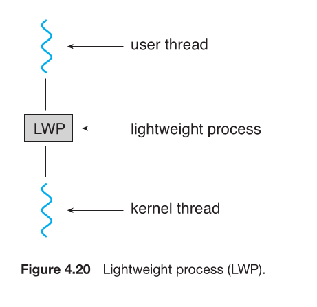

This section addresses a complex but crucial issue in advanced multithreading models: how the user-level thread library and the operating system kernel coordinate to manage threads efficiently. This coordination is essential for the **many-to-many** and **two-level** models (discussed in **Section 4.3.3**) to work effectively.

#### **The Need for an Intermediate Layer: Lightweight Processes (LWPs)**

In many-to-many and two-level models, there isn't a direct one-to-one mapping between user threads and kernel threads. To manage this, systems introduce an intermediate data structure called a **Lightweight Process (LWP)**.

- **Think of an LWP as a "Virtual Processor":** From the perspective of the user-thread library, an LWP looks like a virtual CPU core on which it can schedule a user thread to run. **Go to Figure 4.20** to see this relationship visually.
- **The Connection to the Kernel:** Each LWP is attached to a single kernel thread. It is these **kernel threads** that the operating system scheduler actually places onto the **physical processors** (the real CPU cores).
- **The Chain of Blocking:** If a kernel thread blocks (for example, because it made a system call to read from a disk), the LWP attached to it also blocks. Consequently, the user-level thread that is currently running on that LWP blocks as well.

#### **How Many LWPs Does an Application Need?**

The number of LWPs assigned to a process determines its level of concurrency.

- **CPU-bound Application:** If an application's threads are mostly doing computation (CPU-bound), and it's running on a single-core machine, it only needs **one LWP**. Only one thread can run at a time anyway.
- **I/O-bound Application:** If an application has threads that frequently make blocking I/O requests (like reading files or waiting for network data), it needs **multiple LWPs**. Each thread that executes a blocking system call requires its own LWP to wait on. If you have five threads making simultaneous blocking calls but only four LWPs, the fifth thread will be stuck and cannot proceed until an LWP becomes free.

#### **The Solution: Scheduler Activations and Upcalls**

**Scheduler activation** is a specific scheme designed to facilitate intelligent communication between the kernel and the user-thread library. The goal is to allow the kernel to dynamically adjust the number of LWPs for optimal performance.

Here's how it works:

1. **The Kernel Provides Resources:** The kernel gives the application a set of virtual processors (LWPs). The application's thread library is responsible for scheduling its many user threads onto these available LWPs.
2. **The Kernel Sends Notifications (Upcalls):** The kernel proactively informs the application's thread library about important events. This notification from the kernel to the user-level library is called an **upcall**. An upcall is essentially a "callback" from the kernel. The function in the thread library that handles this upcall is called an **upcall handler**, and it must run on an LWP.

#### **The Upcall Process in Action**

Let's trace a common scenario:

**Scenario 1: A Thread is About to Block**

- A user thread, running on an LWP, invokes a blocking system call (like `read()`).
- The **kernel**, before putting the kernel thread (and thus the LWP) to sleep, makes an **upcall** to the application. This upcall says: "Hey, thread X is about to block."
- The kernel, recognizing that the process is about to lose an execution resource, allocates a **new LWP** to the application.
- The application runs an **upcall handler** on this new LWP. This handler:
  - Saves the state of the blocking user thread.
  - Marks the original LWP (the one that is now blocked) as being in a "blocked" state.
  - Looks at its ready queue and schedules a different, runnable user thread onto the *new* LWP.
- **Result:** The application has maintained its level of concurrency. Although one LWP is blocked, a new one was provided, and a different user thread can continue executing.

**Scenario 2: A Blocked Thread Becomes Ready**

- The I/O operation that the blocked thread was waiting for completes.
- The **kernel** makes another **upcall** to the thread library, informing it that the thread is now unblocked.
- This upcall handler also needs an LWP to run on. The kernel may allocate a new one or temporarily preempt a running user thread.
- The upcall handler marks the previously blocked thread as runnable again.
- The thread library can now schedule this newly unblocked thread onto an available LWP.

**In summary,** scheduler activations create a partnership. The kernel manages the physical resources (CPUs) and informs the user-level library about important events via upcalls. The user-level library, which has the best knowledge of its own threads' needs and states, then makes intelligent scheduling decisions. This cooperation allows the system to dynamically adjust to the workload, ensuring that runnable user threads always have LWPs to run on, even when others are blocked.

## **4.7 Operating-System Examples**

This section provides concrete examples of how the threading concepts we've discussed are implemented in real-world operating systems, starting with Microsoft Windows.

### **4.7.1 Windows Threads**

In the Windows operating system, every application runs as a separate process, and each process can contain one or more threads. Windows implements the **one-to-one threading model** (as described in **Section 4.3.2**), meaning every user-level thread is directly associated with a unique kernel-level thread.

#### **Components of a Windows Thread**

Each thread in Windows is an executable entity that contains the following key components:

- **A Thread ID:** A unique number that identifies the thread.
- **A Register Set:** Represents the current state of the CPU's registers for this thread.
- **A Program Counter (PC):** Points to the next instruction in the thread to be executed.
- **Two Stacks:**
  - A **User Stack:** Used when the thread is executing in user mode (running its own code).
  - A **Kernel Stack:** Used when the thread executes in kernel mode (e.g., during a system call).
- **A Private Storage Area:** Used by various run-time libraries and Dynamic Link Libraries (DLLs).

The register set, stacks, and private storage area are collectively known as the **context** of the thread. The OS must save and restore this context during every thread switch.

#### **Primary Data Structures of a Windows Thread**

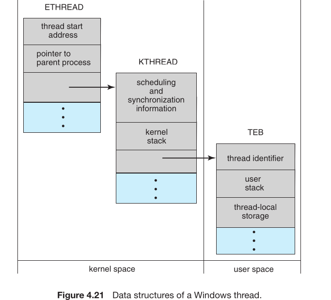

The Windows kernel manages threads using three main data structures. The relationship between these structures is illustrated in **Figure 4.21**.

**1. ETHREAD (Executive Thread Block)**

- **Location:** Exists entirely in **kernel space** (only the operating system can access it).
- **Key Contents:**
  - A pointer to the process to which the thread belongs.
  - The starting address of the routine where the thread begins execution.
  - A pointer to the corresponding **KTHREAD** structure.

**2. KTHREAD (Kernel Thread Block)**

- **Location:** Exists entirely in **kernel space**.
- **Key Contents:**
  - Scheduling and synchronization information for the thread.
  - The **kernel stack** (used when the thread is running in kernel mode).
  - A pointer to the **TEB** (Thread Environment Block).

**3. TEB (Thread Environment Block)**

- **Location:** Exists in **user space**. This allows the thread to access its own information efficiently while it is running in user mode without needing to switch to kernel mode.
- **Key Contents:**
  - The **thread identifier**.
  - The **user-mode stack**.
  - An array for **thread-local storage (TLS)**, which we discussed in **Section 4.6.4**.

**Summary of the Data Flow (from Figure 4.21):** The **ETHREAD** points to the **KTHREAD**, which contains the kernel-level details. The **KTHREAD**, in turn, points to the **TEB**, which holds the user-accessible information. This separation ensures that user applications can access their own thread-specific data efficiently via the TEB, while the kernel maintains full control and security through the ETHREAD and KTHREAD structures.

### **4.7.2 Linux Threads**

Linux takes a unique and philosophically different approach to threads compared to Windows. The core idea is that **Linux does not distinguish between processes and threads** at the kernel level. Instead, Linux uses the more general term **task** to refer to any flow of control within a program.

#### **The Unified Model: `fork()`, `clone()`, and Sharing**

Linux provides two primary mechanisms for creating new flows of control:

1. **`fork()`:** This is the traditional system call, described in **Chapter 3**, which creates a new process. The child process gets a *copy* of the parent's resources (memory, file descriptors, etc.).
2. **`clone()`:** This is the system call used to create what other systems call "threads." The key to `clone()` is that it allows the programmer to explicitly define *what resources are shared* between the parent and the new child task.

#### **How `clone()` Works: The Power of Flags**

The behavior of `clone()` is controlled by a set of flags passed as parameters. These flags determine which data structures the parent and child will share. **Go to Figure 4.22** to see some of the key flags.

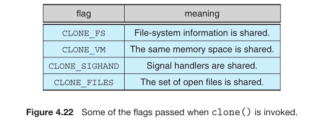

- **Creating a Thread (High Sharing):** If you invoke `clone()` with flags like:
  - `CLONE_VM` (share the same memory space)
  - `CLONE_FS` (share file-system information like the current working directory)
  - `CLONE_FILES` (share the same set of open files)
  - `CLONE_SIGHAND` (share signal handlers) ...then the new task is a **thread**. It shares most of its resources with the parent, which is the defining characteristic of threads within a process.
- **Creating a Process (No Sharing):** If you invoke `clone()` with *none* of these sharing flags set, the new task does not share resources with its parent. This results in behavior functionally equivalent to the `fork()` system call, creating a separate **process**.

#### **Kernel Implementation: `struct task_struct`**

This flexible sharing is possible because of how Linux represents a task in the kernel. The kernel maintains a data structure for each task called `struct task_struct`.

Crucially, this structure does not store the task's data directly. Instead, it contains **pointers to other data structures** that hold the actual information, such as:

- A structure for the list of open files.
- A structure for signal-handling information.
- A structure for virtual memory (mm_struct).

**How `fork()` and `clone()` work under the hood:**

- When `fork()` is called, the kernel creates a new `task_struct` and then creates *new copies* of all the data structures that the `task_struct` points to.
- When `clone()` is called, the kernel creates a new `task_struct`, but depending on the flags, it may simply *copy the pointers* from the parent's `task_struct` instead of creating new copies of the data structures themselves. For example, if `CLONE_FILES` is set, the new task's `task_struct` will point to the *same* "open files" data structure as its parent.

#### **Extension to Containers**

The flexibility of `clone()` goes beyond just threads and processes. The same mechanism is the foundation for **containers**, a lightweight virtualization technique introduced in **Chapter 1**.

- Just as certain flags allow you to create a task that shares most resources (a thread) or shares very few (a process), there are other flags (like `CLONE_NEWPID`, `CLONE_NEWNET`) that can be passed to `clone()` to create an isolated environment known as a **container**.
- These flags create a new, isolated namespace for resources like process IDs, network interfaces, and users, making the task behave as if it's running on its own separate Linux system, even though it's sharing the same kernel.

Containers will be covered in more detail in **Chapter 18**.

**In summary,** Linux uses a unified task model. The distinction between a "process" and a "thread" is merely a matter of which resources are shared, controlled by the flags passed to the `clone()` system call. This design provides immense flexibility, allowing the creation of everything from fully independent processes to tightly-coupled threads and isolated containers, all using the same underlying kernel mechanism.

## **4.8 Summary**

This chapter has provided a comprehensive overview of threads and concurrency. Here are the key takeaways:

- **What is a Thread?** A thread is a basic unit of CPU utilization. Threads within the same process share the process's resources, such as code, data, and files.
- **Benefits of Multithreading:** There are four main advantages:
  1. **Responsiveness:** Allows a program to remain interactive even if part of it is blocked or performing a long operation.
  2. **Resource Sharing:** Threads share memory and resources of their process by default, making data sharing easy.
  3. **Economy:** Creating and managing threads is much faster and less resource-intensive than creating new processes.
  4. **Scalability:** On multicore systems, multithreading allows an application to run faster by executing in parallel on multiple cores.
- **Concurrency vs. Parallelism:**
  - **Concurrency:** Multiple threads are making progress. This is possible on a single CPU core through time-slicing.
  - **Parallelism:** Multiple threads are executing *simultaneously*. This requires a multicore system with multiple CPUs.
- **Challenges of Multithreading:** Writing multithreaded programs is difficult. Key challenges include dividing work and data, managing data dependencies, and the complex task of testing and debugging.
- **Data vs. Task Parallelism:**
  - **Data Parallelism:** The same operation is performed on different subsets of the same data across multiple cores.
  - **Task Parallelism:** Different tasks (operations) are distributed across multiple cores.
- **Threading Models (User-to-Kernel Mapping):**
  - **Many-to-One:** Many user threads map to a single kernel thread (limited concurrency).
  - **One-to-One:** Each user thread maps to its own kernel thread (provides more concurrency).
  - **Many-to-Many:** Many user threads are multiplexed to a smaller or equal number of kernel threads (offers flexibility and good concurrency).
- **Thread Libraries:** APIs for creating and managing threads. The primary examples are:
  - **Pthreads:** A standard for POSIX systems (UNIX, Linux, macOS).
  - **Windows Threads:** The native threading API for the Windows operating system.
  - **Java Threads:** Managed within the Java Virtual Machine (JVM), making them portable across different operating systems.
- **Implicit Threading:** A modern approach where the programmer defines tasks, and the compiler, API, or runtime framework (like thread pools, fork-join, or Grand Central Dispatch) automatically handles the creation and management of the threads. This reduces the complexity for the programmer.
- **Thread Cancellation:**
  - **Asynchronous Cancellation:** Immediately terminates the target thread. This is dangerous as it can lead to resource leaks and data corruption.
  - **Deferred Cancellation:** The target thread checks for cancellation requests and terminates itself at a safe point. This is the preferred and safer method.
- **Linux's Unique Approach:** Linux does not have a separate concept for processes and threads at the kernel level. It uses the general term **task**. The `clone()` system call, with its specific flags, determines the level of resource sharing, creating anything from a fully independent process to a tightly-coupled thread.